# Tarea 1 Estadística y Probabilidad

#### Gráfica de porcentajes

Generamos la gráfica de porcentajes.

```r
par(mar=c(12,4,4,2))
tabla <- table(resena_hotel); (tabla)
```

```
## resena_hotel
##    1 estrella 1.5 estrellas   2 estrellas 2.5 estrellas   3 estrellas
##             5             5             3             1             1
## 3.5 estrellas   4 estrellas 4.5 estrellas   5 estrellas
##             4             6             7             3
```

```r
porcentajes <-  round(prop.table(tabla)* 100, 1); (porcentajes)
```

```
## resena_hotel
##    1 estrella 1.5 estrellas   2 estrellas 2.5 estrellas   3 estrellas
##          14.3          14.3           8.6           2.9           2.9
## 3.5 estrellas   4 estrellas 4.5 estrellas   5 estrellas
##          11.4          17.1          20.0           8.6
```

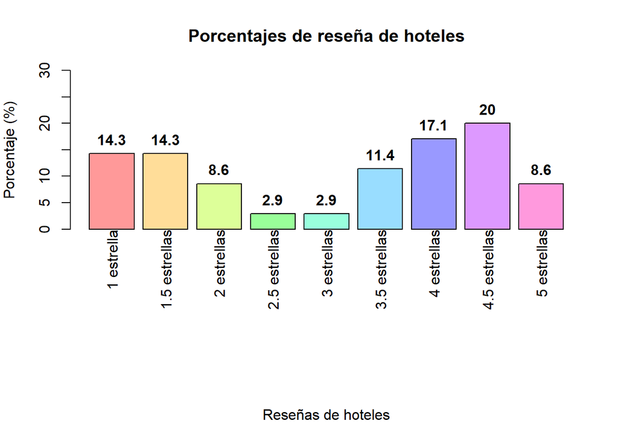

```r
gp<- barplot(porcentajes, col = rainbow(length(tabla),0.4),
    main = "Porcentajes de reseña de hoteles",
    xlab = "",
    names.arg="",
    ylab="Porcentaje (%)",
    ylim=c(0,30),
        )

title(xlab="Reseñas de hoteles",line=10)

#Etiquetas rotadas
text(x=gb,
     y=par("usr")[3]-0.1,
     labels=names(contador),
     srt=90,
     adj=1,
     xpd=TRUE,
     cex=1)

# Agregar valores encima de cada barra
text(x=gp,
     y=porcentajes,
     labels=porcentajes,
     pos=3,
     cex=1,
     font=2)
```

#### Gráfica de pasteles

Generamos la gráfica de pasteles.

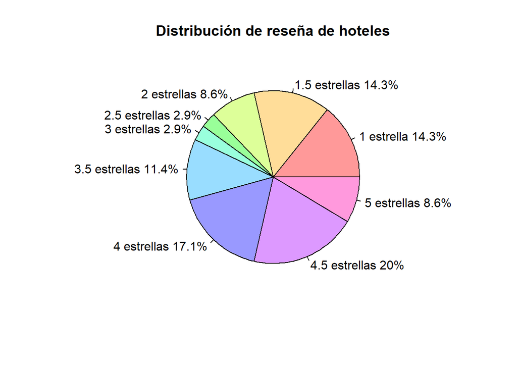

```r
pie(tabla,
    main = "Distribución de reseña de hoteles",
    col = rainbow(length(tabla),0.4),
    labels = paste0(names(tabla)," ",porcentajes, "%"))
```

#### Gráfica de ovija

Generamos la gráfica de ojiva

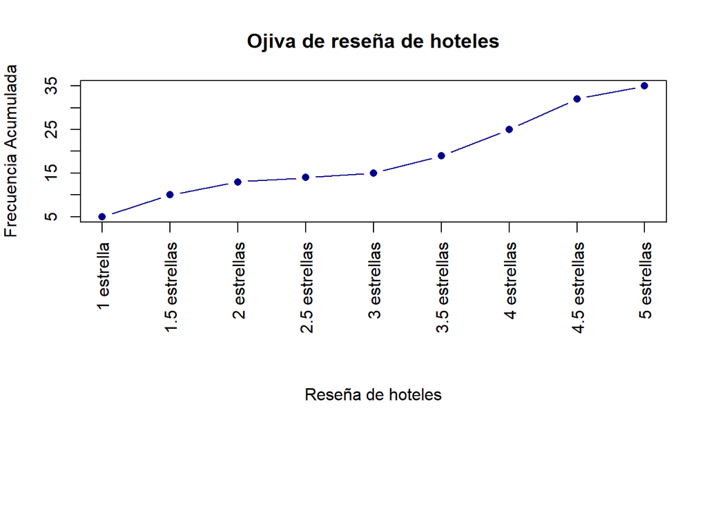

```r
par(mar=c(14,4,4,2))
frec_acum <- cumsum(table(factor(resena_hotel, levels = niveles)))
plot(frec_acum, type = "b", pch = 16, col = "darkblue",
     main = "Ojiva de reseña de hoteles",
     xlab = "",
     names.arg="",
     ylab = "Frecuencia Acumulada",
     xaxt = "n")
title(xlab="Reseña de hoteles",line=8)
axis(1, at = 1:9, labels = niveles, las = 2)  # el comando las = 2 hace las etiquetas de las clases verticales
```

```r
#---- Fin ----
```

## Ejercicio 7.5 Rangos

### Datos

```r
rangos <- c("Principiante", "Principiante", "Aprendiz", "Intermedio", "Experto", "Intermedio", "Experto", "Aprendiz", "Principiante", "Avanzado", "Intermedio", "Experto", "Experto", "Experto", "Avanzado", "Intermedio", "Intermedio", "Principiante", "Principiante", "Principiante", "Principiante", "Principiante", "Intermedio", "Aprendiz", "Aprendiz", "Aprendiz", "Aprendiz", "Intermedio", "Aprendiz", "Principiante", "Intermedio", "Avanzado", "Avanzado", "Intermedio", "Avanzado", "Principiante", "Intermedio", "Avanzado", "Intermedio", "Avanzado")
```

### Procesamiento de datos

Primero obtenemos un resumen de los datos generados

```r
summary(rangos)
```

```
##    Length     Class      Mode
##        40 character character
```

### Frecuencias

Obtenemos las frecuencias de los datos.

```r
(rangos) #Datos
```

```
##  [1] "Principiante" "Principiante" "Aprendiz"     "Intermedio"   "Experto"
##  [6] "Intermedio"   "Experto"      "Aprendiz"     "Principiante" "Avanzado"
## [11] "Intermedio"   "Experto"      "Experto"      "Experto"      "Avanzado"
## [16] "Intermedio"   "Intermedio"   "Principiante" "Principiante" "Principiante"
## [21] "Principiante" "Principiante" "Intermedio"   "Aprendiz"     "Aprendiz"
## [26] "Aprendiz"     "Aprendiz"     "Intermedio"   "Aprendiz"     "Principiante"
## [31] "Intermedio"   "Avanzado"     "Avanzado"     "Intermedio"   "Avanzado"
## [36] "Principiante" "Intermedio"   "Avanzado"     "Intermedio"   "Avanzado"
```

```r
sort(rangos) #Datos ordenados por clase
```

```
##  [1] "Aprendiz"     "Aprendiz"     "Aprendiz"     "Aprendiz"     "Aprendiz"
##  [6] "Aprendiz"     "Aprendiz"     "Avanzado"     "Avanzado"     "Avanzado"
## [11] "Avanzado"     "Avanzado"     "Avanzado"     "Avanzado"     "Experto"
## [16] "Experto"      "Experto"      "Experto"      "Experto"      "Intermedio"
## [21] "Intermedio"   "Intermedio"   "Intermedio"   "Intermedio"   "Intermedio"
## [26] "Intermedio"   "Intermedio"   "Intermedio"   "Intermedio"   "Intermedio"
## [31] "Principiante" "Principiante" "Principiante" "Principiante" "Principiante"
## [36] "Principiante" "Principiante" "Principiante" "Principiante" "Principiante"
```

```r
contador <- table(rangos) #Frecuencia de los datos
(contador)
```

```
## rangos
##     Aprendiz     Avanzado      Experto   Intermedio Principiante
##            7            7            5           11           10
```

### Proporciones

Obtenemos las proporciones.

```r
prop.table(table(rangos)) #Proporciones
```

```
## rangos
##     Aprendiz     Avanzado      Experto   Intermedio Principiante
##        0.175        0.175        0.125        0.275        0.250
```

### Medidas de tendencia central

#### Moda

Obtenemos la moda

```r
# Función para detectar modalidad
max_frecuencia <- max(contador)
modas <- names(contador)[contador == max_frecuencia]

# Identificar e imprimir resultado
if(length(modas) == 1) {
  cat("UNIMODAL - Moda:", modas)
} else if(length(modas) == 2) {
  cat("BIMODAL - Modas:", paste(modas, collapse = " y "))
} else {
  cat("Hay más de dos clases con mayor frecuencia por lo tanto no hay moda")
}
```

```
## UNIMODAL - Moda: Intermedio
```

#### Mediana

Obtenemos la mediana

```r
mediana_rangos <- function(rangos) {
  niveles <- c("Principiante", "Aprendiz", "Intermedio", "Avanzado", "Experto") #Con esto ordenamos nuestras clases de menor a mayor rango

  # Convertir a numérico, ordenar y reconvertir a texto
  numerico_ord <- sort(sapply(rangos, function(x) which(niveles == x)))
  (numerico_ord)
  texto_ord <- niveles[numerico_ord]
  cat("Datos ordenados:   ", paste(texto_ord, collapse = ", "), "\n")

  # Calcular mediana
  mediana<- median(numerico_ord)
  resultado <- niveles[round(mediana)]

  cat("La mediana es:", resultado, "\n")
  return(resultado)
}

resultado <- mediana_rangos(rangos)
```

[output not shown]

#### Media

A pesar de tener datos que se pueden ordenar, no se puede tener una media debido a que no tenemos datos numéricos con los cuales calcular.

### Medidas de localización

#### Cuartiles

```r
niveles <- c("Principiante", "Aprendiz", "Intermedio", "Avanzado", "Experto")

numerico <- sapply(rangos, function(x) which(niveles == x))
numerico_ord <- sort(numerico)

q1 <- niveles[round(quantile(numerico_ord, 0.25))]
(q1)
```

```
## [1] "Aprendiz"
```

```r
q2 <- niveles[round(quantile(numerico_ord, 0.50))]
(q2)
```

```
## [1] "Intermedio"
```

```r
q3 <- niveles[round(quantile(numerico_ord, 0.75))]
(q3)
```

```
## [1] "Avanzado"
```

Calculemos el valor máximo y el valor mínimo para los datos

```r
mi_min <- min(rangos);
(mi_min)
```

```
## [1] "Aprendiz"
```

```r
mi_max <- max(rangos);
(mi_max)
```

```
## [1] "Principiante"
```

### Diagrama de caja y brazos

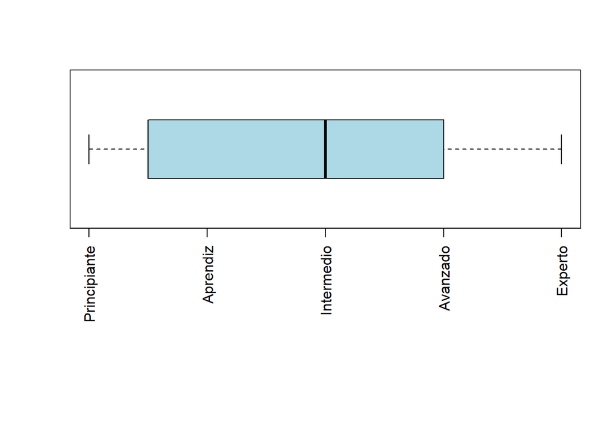

```r
par(mar=c(12,4,4,2))
boxplot(numerico_ord, horizontal = TRUE, col = "lightblue", xaxt = "n")
axis(1, at = 1:5, labels = niveles, las=2)
```

### Gráficos

Comenzamos a graficar.

#### Gráfica con el comando *barplot*

Generemos la gráfica de barras.

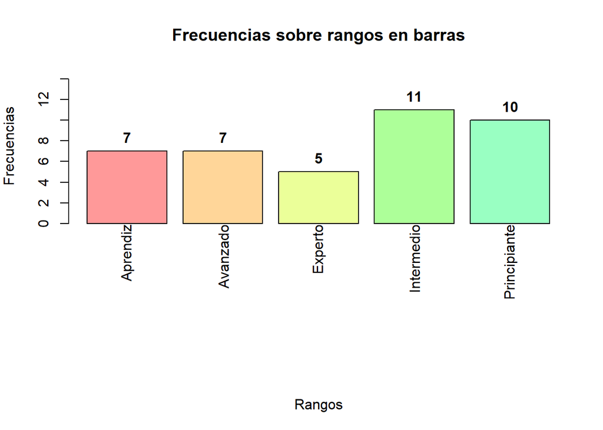

```r
par(mar=c(12,4,4,2))
gb<-barplot(contador, col=rainbow(10,0.4),
        main="Frecuencias sobre rangos en barras",
        xlab="",
        names.arg="",
        ylab="Frecuencias",
        ylim=c(0,15),
        )
title(xlab="Rangos",line=10)

#Etiquetas rotadas
text(x=gb,
     y=par("usr")[3]-0.1,
     labels=names(contador),
     srt=90,
     adj=1,
     xpd=TRUE,
     cex=1)

# Agregar valores encima de cada barra
text(x=gb,
     y=contador,
     labels=contador,
     pos=3,
     cex=1,
     font=2)
```

#### Gráfica de porcentajes

Generamos la gráfica de porcentajes.

```r
par(mar=c(12,4,4,2))
tabla <- table(rangos); (tabla)
```

```
## rangos
##     Aprendiz     Avanzado      Experto   Intermedio Principiante
##            7            7            5           11           10
```

```r
porcentajes <-  round(prop.table(tabla)* 100, 1); (porcentajes)
```

```
## rangos
##     Aprendiz     Avanzado      Experto   Intermedio Principiante
##         17.5         17.5         12.5         27.5         25.0
```

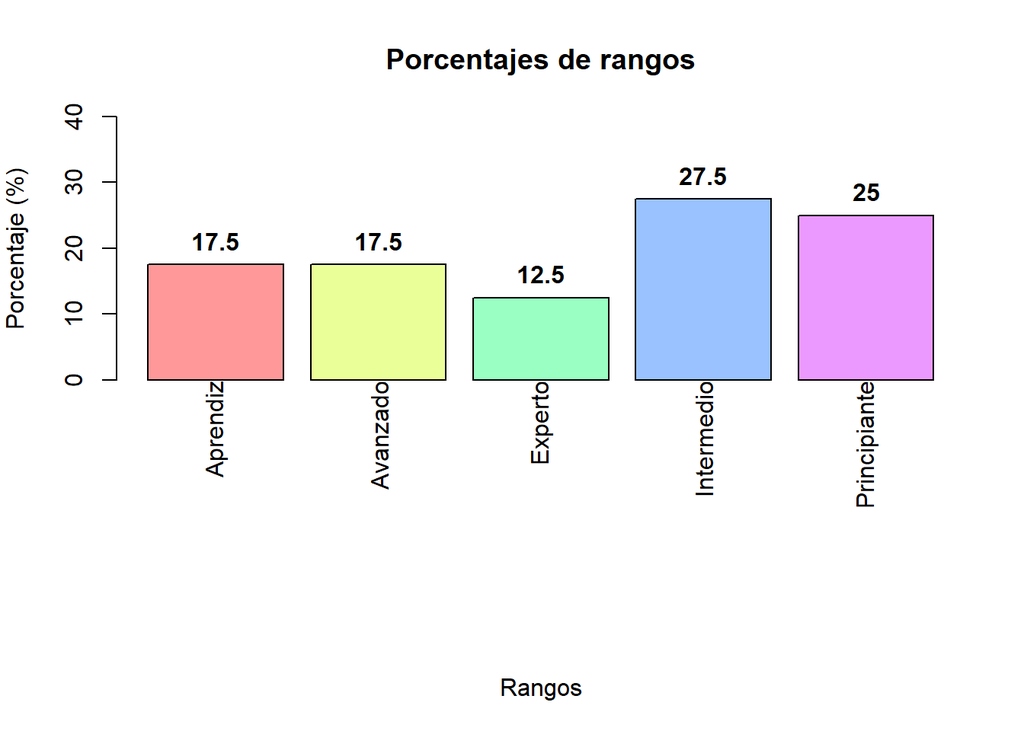

```r
gp<- barplot(porcentajes, col = rainbow(length(tabla),0.4),
    main = "Porcentajes de rangos",
    xlab = "",
    names.arg="",
    ylab="Porcentaje (%)",
    ylim=c(0,40),
        )

title(xlab="Rangos",line=10)

#Etiquetas rotadas
text(x=gb,
     y=par("usr")[3]-0.1,
     labels=names(contador),
     srt=90,
     adj=1,
     xpd=TRUE,
     cex=1)

# Agregar valores encima de cada barra
text(x=gp,
     y=porcentajes,
     labels=porcentajes,
     pos=3,
     cex=1,
     font=2)
```

#### Gráfica de pasteles

Generamos la gráfica de pasteles.

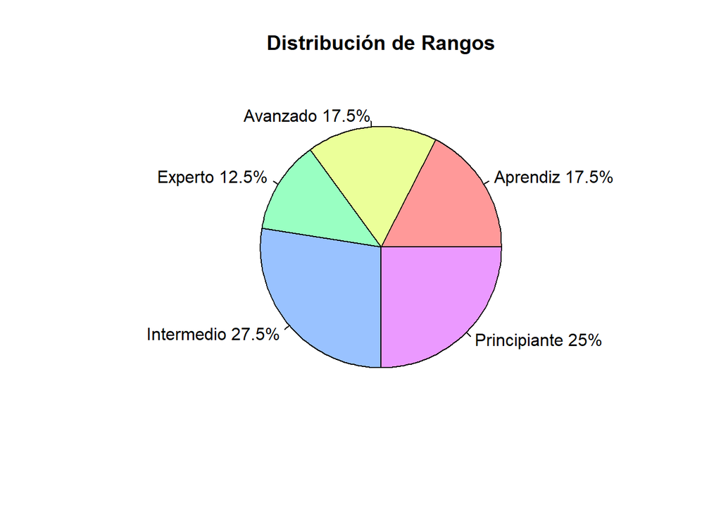

```r
pie(tabla,
    main = "Distribución de Rangos",
    col = rainbow(length(tabla),0.4),
    labels = paste0(names(tabla)," ",porcentajes, "%"))
```

#### Gráfica de ovija

Generamos la gráfica de ojiva

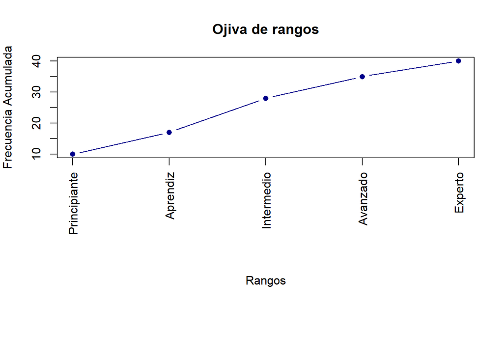

```r
par(mar=c(14,4,4,2))
frec_acum <- cumsum(table(factor(rangos, levels = niveles)))
plot(frec_acum, type = "b", pch = 16, col = "darkblue",
     main = "Ojiva de rangos",
     xlab = "",
     names.arg="",
     ylab = "Frecuencia Acumulada",
     xaxt = "n")
title(xlab="Rangos",line=8)
axis(1, at = 1:5, labels = niveles, las = 2)  # el comando las = 2 hace las etiquetas de las clases verticales
```

```r
#---- Fin ----
```

# Ejercicio 8: Variables Cuantitativas Discretas

## Ejercicio 8.1 Número de hijos en una familia

### Datos

```r
hijos <- c(2, 2, 4, 4, 1, 3, 1, 3, 3, 3, 5, 2, 1, 5, 3, 3, 3, 3, 1, 3, 3, 2, 5, 5, 2, 5, 2, 3, 1, 3)
```

### Procesamiento de datos (Ordenar)

Primero obtenemos un resumen de los datos generados

```r
summary(hijos)
```

```
##    Min. 1st Qu.  Median    Mean 3rd Qu.    Max.
##   1.000   2.000   3.000   2.867   3.000   5.000
```

Al ser variables de tipo cuantitativa discretas se pueden ordenar.

### Frecuencias (Clasificar)

Obtenemos las frecuencias de los datos.

```r
(hijos) #Datos
```

```
##  [1] 2 2 4 4 1 3 1 3 3 3 5 2 1 5 3 3 3 3 1 3 3 2 5 5 2 5 2 3 1 3
```

```r
hijos_ord<- sort(hijos) #Datos ordenados por clase
(hijos_ord)
```

```
##  [1] 1 1 1 1 1 2 2 2 2 2 2 3 3 3 3 3 3 3 3 3 3 3 3 4 4 5 5 5 5 5
```

```r
contador <- table(hijos) #Frecuencia de los datos
(contador)
```

```
## hijos
##  1  2  3  4  5
##  5  6 12  2  5
```

```r
cte<- 9
```

### Proporciones

Obtenemos las proporciones.

```r
prop.table(table(hijos)) #Proporciones
```

```
## hijos
##          1          2          3          4          5
## 0.16666667 0.20000000 0.40000000 0.06666667 0.16666667
```

### Medidas de tendencia central

#### Moda

Obtenemos la moda

```r
# Función para detectar modalidad
max_frecuencia <- max(contador)
modas <- names(contador)[contador == max_frecuencia]

# Identificar e imprimir resultado
if(length(modas) == 1) {
  cat("UNIMODAL - Moda:", modas)
} else if(length(modas) == 2) {
  cat("BIMODAL - Modas:", paste(modas, collapse = " y "))
} else {
  cat("Hay más de dos clases con mayor frecuencia por lo tanto no hay moda")
}
```

```
## UNIMODAL - Moda: 3
```

#### Mediana

Obtenemos la mediana

```r
  # Calcular mediana
  mediana<- median(hijos)
  cat("La mediana es:", mediana, "\n")
```

```
## La mediana es: 3
```

#### Media

Obtenemos la media

```r
media<-mean(hijos)
cat("La media es:", media, "\n")
```

```
## La media es: 2.866667
```

### Medidas de localización

#### Cuartiles

```r
cuantiles <- quantile(hijos_ord); (cuantiles)
```

```
##   0%  25%  50%  75% 100%
##    1    2    3    3    5
```

```r
Q1 <- cuantiles[2]; (Q1)
```

```
## 25%
##   2
```

```r
Q2 <- cuantiles[3]; (Q2)
```

```
## 50%
##   3
```

```r
Q3 <- cuantiles[4]; (Q3)
```

```
## 75%
##   3
```

Calculemos el valor máximo y el valor mínimo para los datos

```r
mi_min <- min(hijos);
(mi_min)
```

```
## [1] 1
```

```r
mi_max <- max(hijos);
(mi_max)
```

```
## [1] 5
```

### Diagrama de caja y brazos

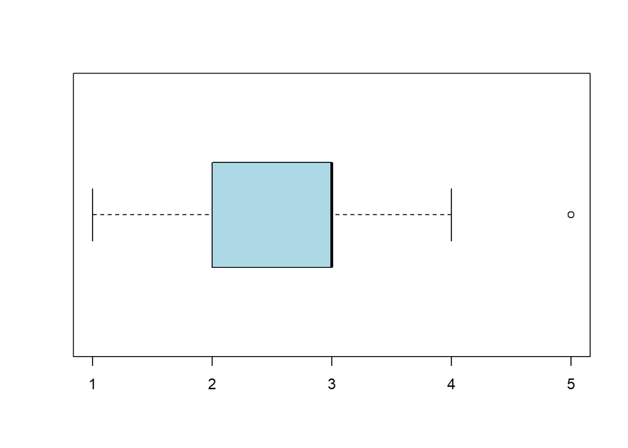

```r
boxplot(hijos_ord, horizontal = TRUE, col = "lightblue")
```

### Medidas de dispersión

#### Varianza

```r
varianza <- var(hijos); (varianza)
```

```
## [1] 1.636782
```

#### Desviación estándar

```r
DesvEst <- sd(hijos); (DesvEst)
```

```
## [1] 1.279368
```

### Gráficos

Comenzamos a graficar.

#### Gráfica con el comando *barplot*

Generemos la gráfica de barras.

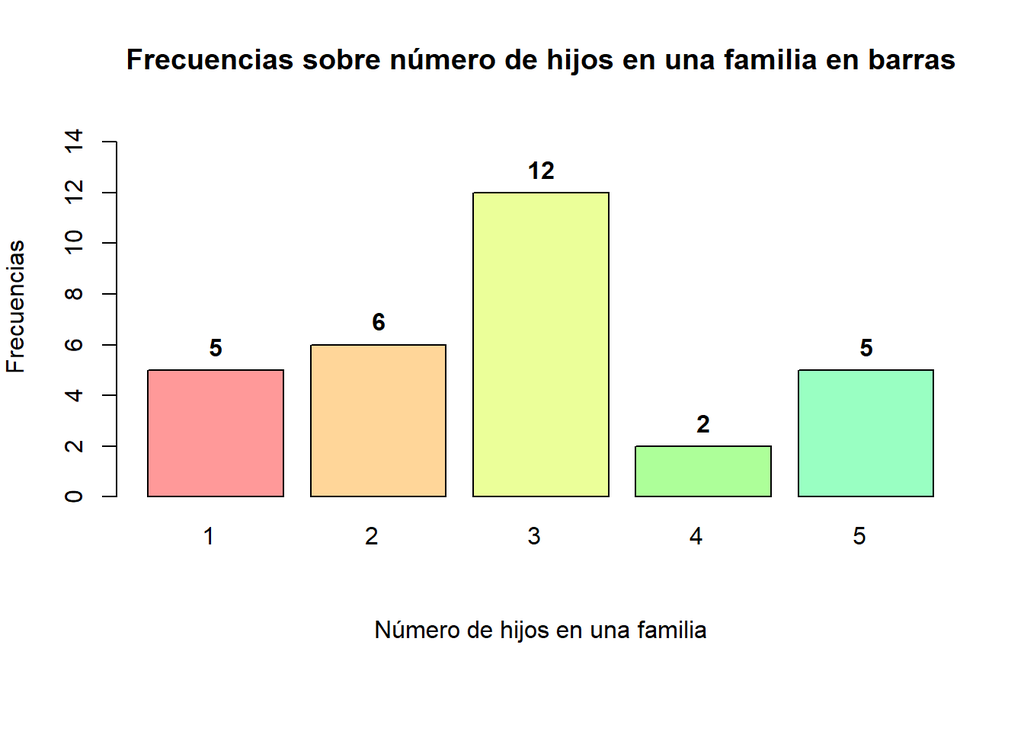

```r
par(mar=c(8,4,4,2))
gb<-barplot(contador, col=rainbow(10,0.4),
        main="Frecuencias sobre número de hijos en una familia en barras",
        xlab="",
        names.arg="",
        ylab="Frecuencias",
        ylim=c(0,15),
        )
title(xlab="Número de hijos en una familia",line=4)

#Etiquetas rotadas
text(x=gb,
     y=par("usr")[3]-1.5,
     labels=names(contador),
     srt=0,
     adj=1,
     xpd=TRUE,
     cex=1)

# Agregar valores encima de cada barra
text(x=gb,
     y=contador,
     labels=contador,
     pos=3,
     cex=1,
     font=2)
```

#### Gráfica de porcentajes

Generamos la gráfica de porcentajes.

```r
par(mar=c(8,4,4,2))
tabla <- table(hijos); (tabla)
```

```
## hijos
##  1  2  3  4  5
##  5  6 12  2  5
```

```r
porcentajes <-  round(prop.table(tabla)* 100, 1); (porcentajes)
```

```
## hijos
##    1    2    3    4    5
## 16.7 20.0 40.0  6.7 16.7
```

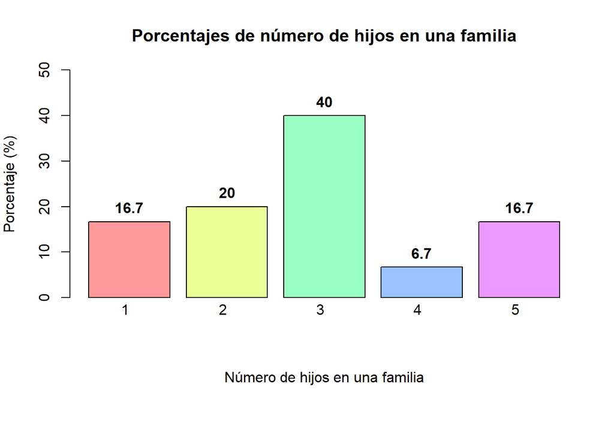

```r
gp<- barplot(porcentajes, col = rainbow(length(tabla),0.4),
    main = "Porcentajes de número de hijos en una familia",
    xlab = "",
    names.arg="",
    ylab="Porcentaje (%)",
    ylim=c(0,50),
        )

title(xlab="Número de hijos en una familia",line=4)

#Etiquetas rotadas
text(x=gb,
     y=par("usr")[3]-2.5,
     labels=names(contador),
     srt=0,
     adj=1,
     xpd=TRUE,
     cex=1)

# Agregar valores encima de cada barra
text(x=gp,
     y=porcentajes,
     labels=porcentajes,
     pos=3,
     cex=1,
     font=2)
```

#### Gráfica de pasteles

Generamos la gráfica de pasteles.

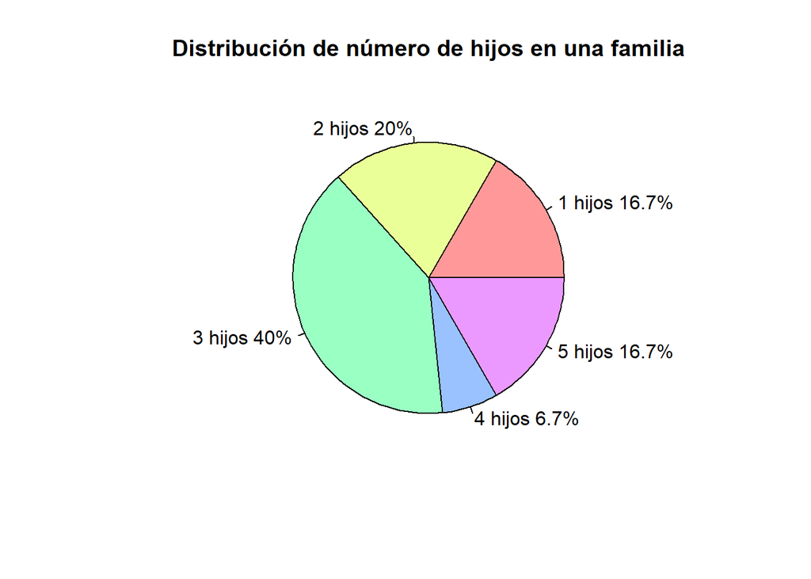

```r
pie(tabla,
    main = "Distribución de número de hijos en una familia",
    col = rainbow(length(tabla),0.4),
    labels = paste0(names(tabla)," hijos ",porcentajes, "%"))
```

#### Gráfica de ojiva

Generamos la gráfica de ojiva

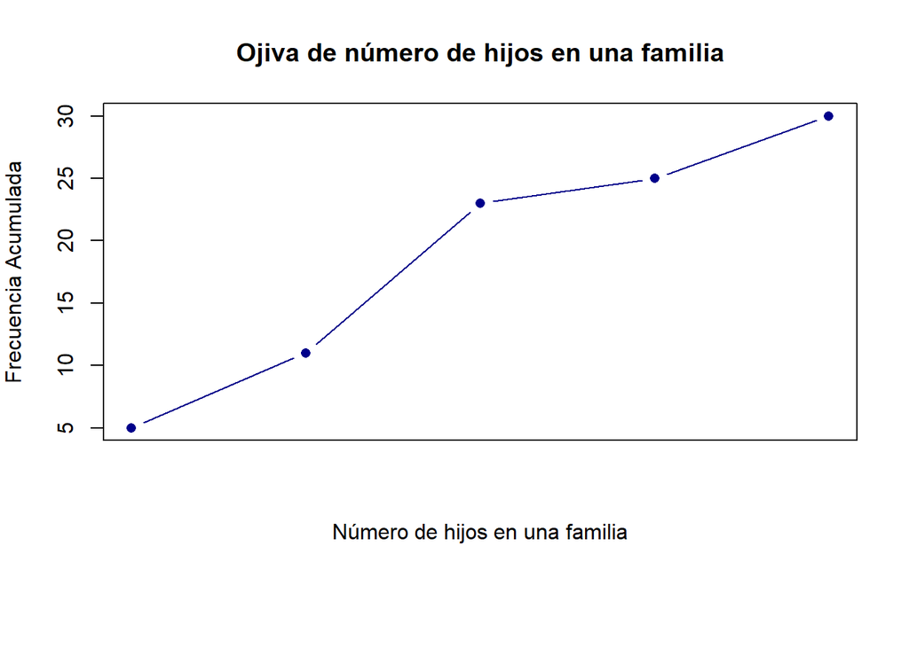

```r
par(mar=c(8,4,4,2))
frec_acum <- cumsum(table(factor(hijos)))
plot(frec_acum, type = "b", pch = 16, col = "darkblue",
     main = "Ojiva de número de hijos en una familia",
     xlab = "Número de hijos en una familia",
     ylab = "Frecuencia Acumulada",
     xaxt = "n")
```

#### Gráfica de dispersión

```r
indices <- 1:10; (indices)
```

```
##  [1]  1  2  3  4  5  6  7  8  9 10
```

```r
t <- cte*indices; (t)
```

```
##  [1]  9 18 27 36 45 54 63 72 81 90
```

```r
mis_deciles <- hijos_ord[t]; (mis_deciles)
```

```
##  [1]  2  3  5 NA NA NA NA NA NA NA
```

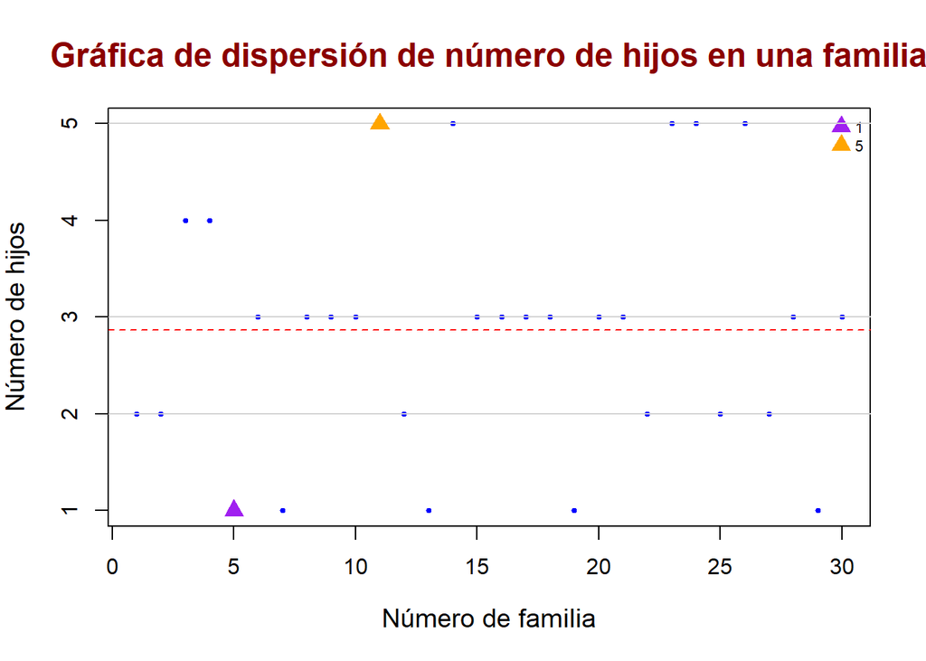

```r
plot(
  hijos,
  main = "Gráfica de dispersión de número de hijos en una familia",
  xlab = "Número de familia",
  ylab = "Número de hijos",
  col = "blue",
  pch = 19,
  cex = 0.5,
  cex.main = 1.5,
  cex.lab = 1.2,
  col.main = "darkred")
legend(
  "topright",                  # ubicación
  legend = c(mi_min,mi_max),    # etiquetas
  pch = 17,
  col=c("purple","orange"),
  pt.cex = 1.5,                # tamaño de los símbolos
  cex = 0.7,
  bty = "n"                    # sin borde en la caja
)
abline(h = media, col = "red", lwd = 1, lty = 2)
abline(h = Q2, col = "lightgreen", lwd = 1, lty = 3)
abline(h = mis_deciles, col = "lightgray", lty = 1.5)
points(which.min(hijos), min(hijos), col = "purple", pch = 17, cex = 1.5)
points(which.max(hijos), max(hijos), col = "orange", pch = 17, cex = 1.5)
```

#### Gráfica combinada

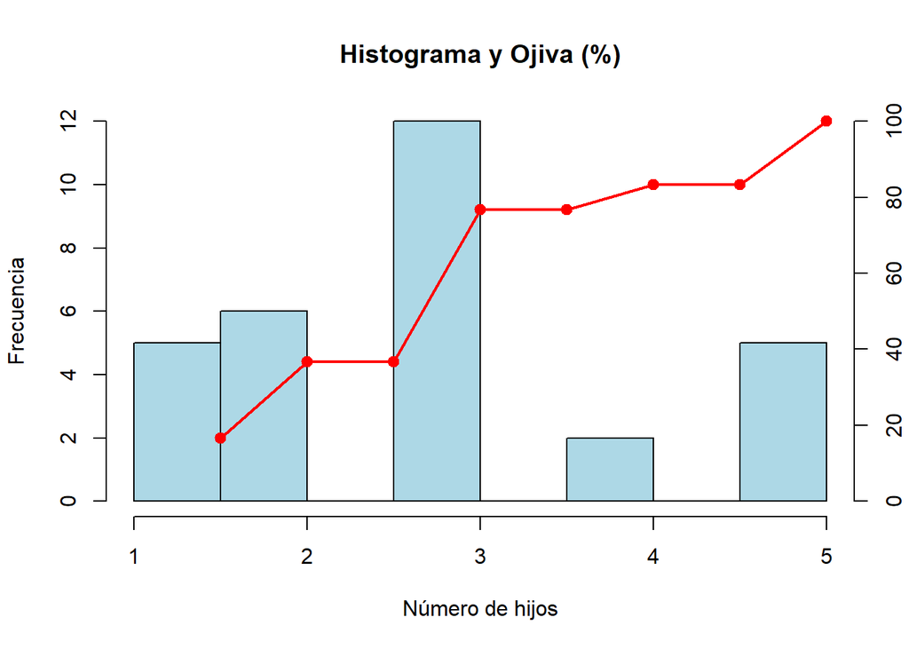

```r
nbreaks <- 10
h <- hist(hijos, breaks = nbreaks, plot = FALSE)
hist(hijos,
     breaks = nbreaks,
     col = "lightblue",
     main = "Histograma y Ojiva (%)",
     xlab = "Número de hijos",
     ylab = "Frecuencia")
freq_acum_pct <- cumsum(h$counts) / sum(h$counts) * 100
x_vals <- h$breaks[-1]
par(new = TRUE)
plot(x_vals, freq_acum_pct,
     type = "o", pch = 19, lwd = 2, col = "red",
     axes = FALSE, xlab = "", ylab = "",
     xlim = range(h$breaks), ylim = c(0, 100))
axis(4)                           # eje derecho
```

```r
#---- Fin ----
```

## Ejercicio 8.2 Número de estudiantes en un salón

### Datos

```r
estudiantes<- c(35, 37, 13, 6, 40, 42, 11, 24, 24, 33, 8, 34, 21, 23, 34, 24, 45, 39, 38, 35, 9, 39, 38, 45, 7, 35, 22, 28, 38, 6, 5, 45, 36, 18, 37, 45, 13, 31, 23, 43)
```

### Procesamiento de datos (Ordenar)

Primero obtenemos un resumen de los datos generados

```r
summary(estudiantes)
```

```
##    Min. 1st Qu.  Median    Mean 3rd Qu.    Max.
##    5.00   20.25   33.50   28.23   38.00   45.00
```

Al ser variables de tipo cuantitativa discretas se pueden ordenar.

### Frecuencias (Clasificar)

Obtenemos las frecuencias de los datos.

```r
(estudiantes) #Datos
```

```
##  [1] 35 37 13  6 40 42 11 24 24 33  8 34 21 23 34 24 45 39 38 35  9 39 38 45  7
## [26] 35 22 28 38  6  5 45 36 18 37 45 13 31 23 43
```

```r
estudiantes_ord<- sort(estudiantes) #Datos ordenados por clase
(estudiantes_ord)
```

```
##  [1]  5  6  6  7  8  9 11 13 13 18 21 22 23 23 24 24 24 28 31 33 34 34 35 35 35
## [26] 36 37 37 38 38 38 39 39 40 42 43 45 45 45 45
```

```r
contador <- table(estudiantes) #Frecuencia de los datos
(contador)
```

```
## estudiantes
##  5  6  7  8  9 11 13 18 21 22 23 24 28 31 33 34 35 36 37 38 39 40 42 43 45
##  1  2  1  1  1  1  2  1  1  1  2  3  1  1  1  2  3  1  2  3  2  1  1  1  4
```

```r
cte<- 9
```

### Proporciones

Obtenemos las proporciones.

```r
prop.table(table(estudiantes)) #Proporciones
```

```
## estudiantes
##     5     6     7     8     9    11    13    18    21    22    23    24    28
## 0.025 0.050 0.025 0.025 0.025 0.025 0.050 0.025 0.025 0.025 0.050 0.075 0.025
##    31    33    34    35    36    37    38    39    40    42    43    45
## 0.025 0.025 0.050 0.075 0.025 0.050 0.075 0.050 0.025 0.025 0.025 0.100
```

### Medidas de tendencia central

#### Moda

Obtenemos la moda

```r
# Función para detectar modalidad
max_frecuencia <- max(contador)
modas <- names(contador)[contador == max_frecuencia]

# Identificar e imprimir resultado
if(length(modas) == 1) {
  cat("UNIMODAL - Moda:", modas)
} else if(length(modas) == 2) {
  cat("BIMODAL - Modas:", paste(modas, collapse = " y "))
} else {
  cat("Hay más de dos clases con mayor frecuencia por lo tanto no hay moda")
}
```

```
## UNIMODAL - Moda: 45
```

#### Mediana

Obtenemos la mediana

```r
  # Calcular mediana
  mediana<- median(estudiantes)
  cat("La mediana es:", mediana, "\n")
```

```
## La mediana es: 33.5
```

#### Media

Obtenemos la media

```r
media<-mean(estudiantes)
cat("La media es:", media, "\n")
```

```
## La media es: 28.225
```

### Medidas de localización

#### Cuartiles

```r
cuantiles <- quantile(estudiantes_ord); (cuantiles)
```

```
##    0%   25%   50%   75%  100%
##  5.00 20.25 33.50 38.00 45.00
```

```r
Q1 <- cuantiles[2]; (Q1)
```

```
##   25%
## 20.25
```

```r
Q2 <- cuantiles[3]; (Q2)
```

```
##  50%
## 33.5
```

```r
Q3 <- cuantiles[4]; (Q3)
```

```
## 75%
##  38
```

Calculemos el valor máximo y el valor mínimo para los datos

```r
mi_min <- min(estudiantes);
(mi_min)
```

```
## [1] 5
```

```r
mi_max <- max(estudiantes);
(mi_max)
```

```
## [1] 45
```

### Diagrama de caja y brazos

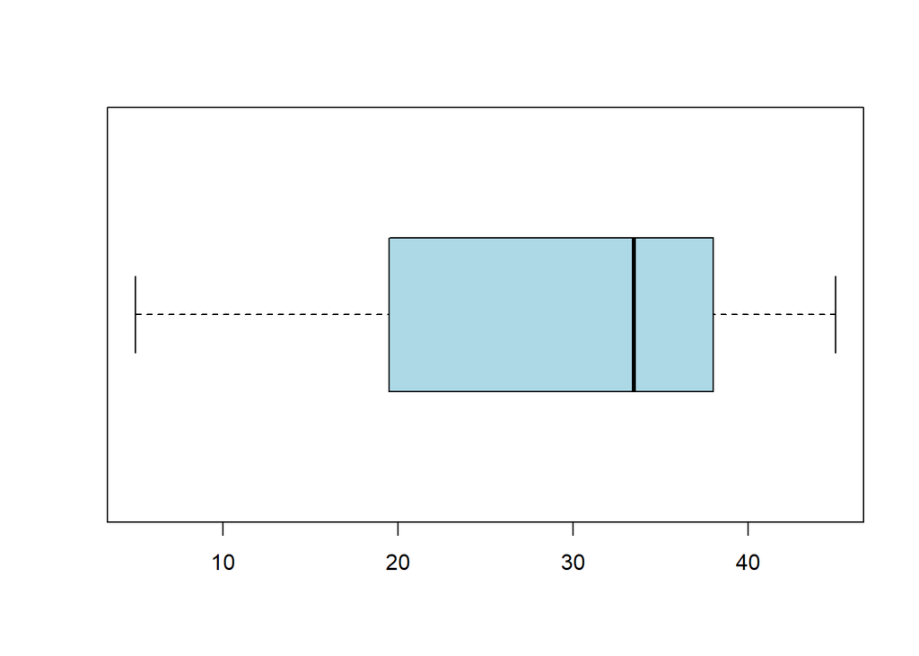

```r
boxplot(estudiantes_ord, horizontal = TRUE, col = "lightblue")
```

### Medidas de dispersión

#### Varianza

```r
varianza <- var(estudiantes); (varianza)
```

```
## [1] 165.666
```

#### Desviación estándar

```r
DesvEst <- sd(estudiantes); (DesvEst)
```

```
## [1] 12.87113
```

### Gráficos

Comenzamos a graficar.

#### Gráfica con el comando *barplot*

Generemos la gráfica de barras.

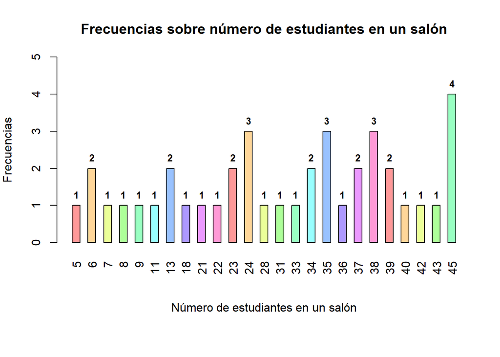

```r
par(mar=c(8,4,4,2))
gb<-barplot(contador, col=rainbow(10,0.4),
        main="Frecuencias sobre número de estudiantes en un salón",
        xlab="",
        names.arg="",
        ylab="Frecuencias",
        ylim=c(0,5),
        space = 1,
        width = 3,
        )
title(xlab="Número de estudiantes en un salón",line=4)

#Etiquetas rotadas
text(x=gb,
     y=par("usr")[3]-0.5,
     labels=names(contador),
     srt=90,
     adj=1,
     xpd=TRUE,
     cex=1,
     space=1)
# Agregar valores encima de cada barra
text(x=gb,
     y=contador,
     labels=contador,
     pos=3,
     cex=0.8,
     font=2)
```

#### Gráfica de porcentajes

Generamos la gráfica de porcentajes.

```r
par(mar=c(8,4,4,2))
tabla <- table(estudiantes); (tabla)
```

```
## estudiantes
##  5  6  7  8  9 11 13 18 21 22 23 24 28 31 33 34 35 36 37 38 39 40 42 43 45
##  1  2  1  1  1  1  2  1  1  1  2  3  1  1  1  2  3  1  2  3  2  1  1  1  4
```

```r
porcentajes <-  round(prop.table(tabla)* 100, 1); (porcentajes)
```

```
## estudiantes
##    5    6    7    8    9   11   13   18   21   22   23   24   28   31   33   34
##  2.5  5.0  2.5  2.5  2.5  2.5  5.0  2.5  2.5  2.5  5.0  7.5  2.5  2.5  2.5  5.0
##   35   36   37   38   39   40   42   43   45
##  7.5  2.5  5.0  7.5  5.0  2.5  2.5  2.5 10.0
```

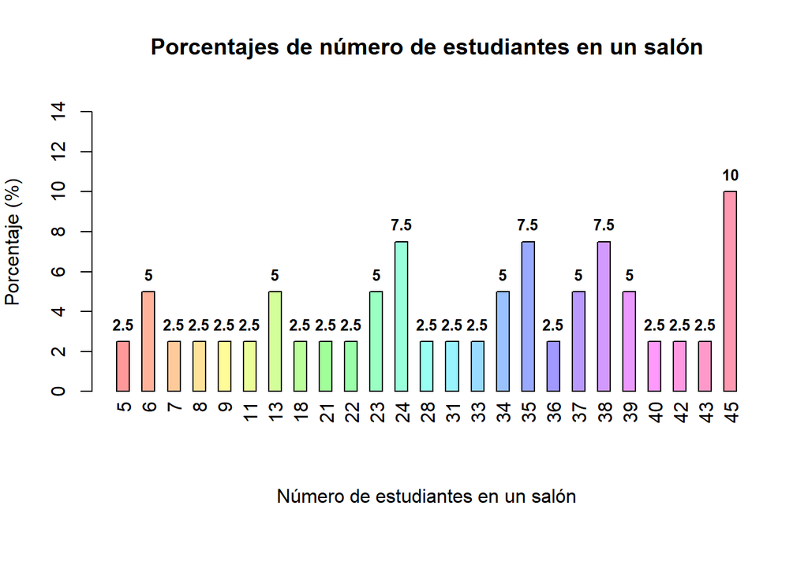

```r
gp<- barplot(porcentajes, col = rainbow(length(tabla),0.4),
    main = "Porcentajes de número de estudiantes en un salón",
    xlab = "",
    names.arg="",
    ylab="Porcentaje (%)",
    ylim=c(0,15),
    space=1,
    width = 3,
        )

title(xlab="Número de estudiantes en un salón",line=4)

#Etiquetas rotadas
text(x=gb,
     y=par("usr")[3]-0.5,
     labels=names(contador),
     srt=90,
     adj=1,
     xpd=TRUE,
     cex=1,
     space=1)
# Agregar valores encima de cada barra
text(x=gp,
     y=porcentajes,
     labels=porcentajes,
     pos=3,
     cex=0.8,
     font=2)
```

#### Gráfica de pasteles

Generamos la gráfica de pasteles.

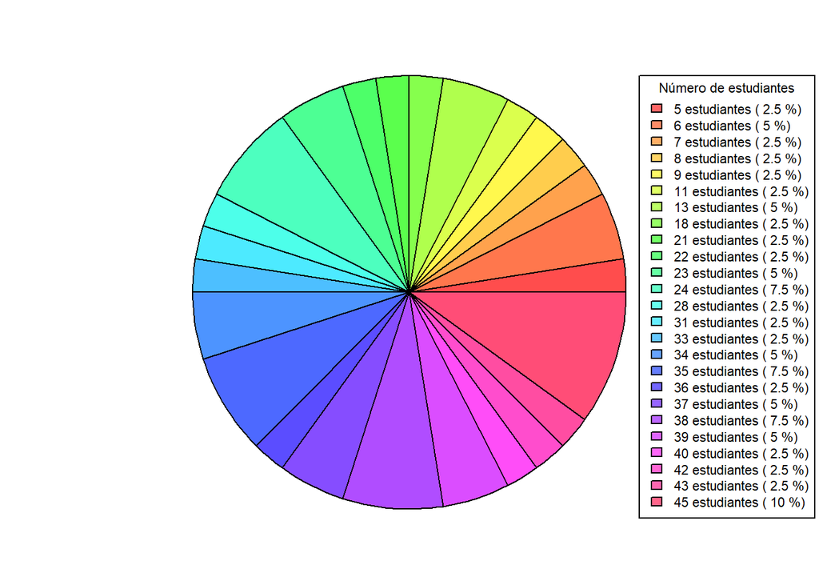

```r
par(pin = c(7, 5))
pie(tabla,
    main = "Distribución de número de estudiantes en un salón",
    col = rainbow(length(tabla), 0.7),
    labels = NA,
    cex.main = 1.5)

#Cuadro de acotaciones a la derecha

legend(x = 0.85, y = 0.8,
       legend = paste(names(tabla), "estudiantes (", porcentajes, "%)"),
       fill = rainbow(length(tabla), 0.6),
       cex = 0.7,
       title = "Número de estudiantes")
```

#### Gráfica de ojiva

Generamos la gráfica de ojiva

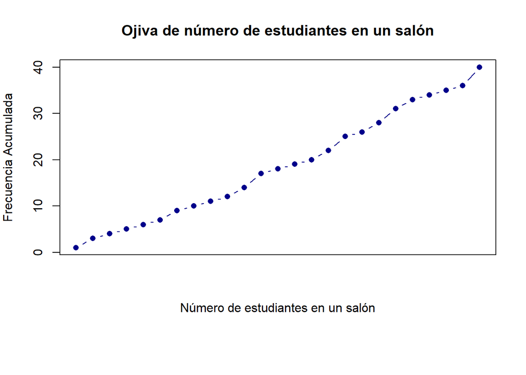

```r
par(mar=c(8,4,4,2))
frec_acum <- cumsum(table(factor(estudiantes)))
plot(frec_acum, type = "b", pch = 16, col = "darkblue",
     main = "Ojiva de número de estudiantes en un salón",
     xlab = "Número de estudiantes en un salón",
     ylab = "Frecuencia Acumulada",
     xaxt = "n")
```

#### Gráfica de dispersión

```r
indices <- 1:10; (indices)
```

```
##  [1]  1  2  3  4  5  6  7  8  9 10
```

```r
t <- cte*indices; (t)
```

```
##  [1]  9 18 27 36 45 54 63 72 81 90
```

```r
mis_deciles <- estudiantes_ord[t]; (mis_deciles)
```

```
##  [1] 13 28 37 43 NA NA NA NA NA NA
```

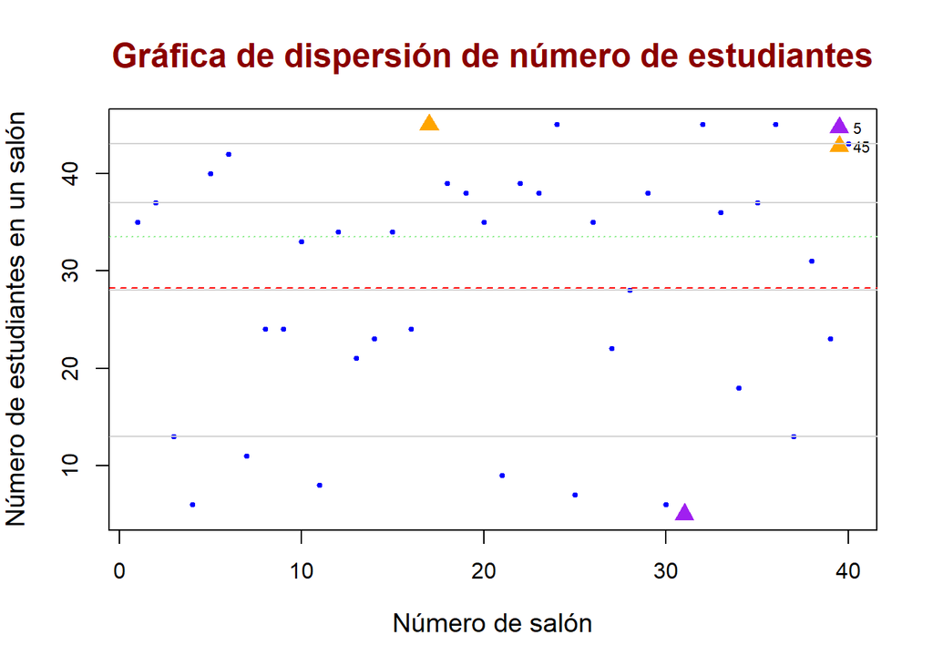

```r
plot(estudiantes,
  main = "Gráfica de dispersión de número de estudiantes",
  xlab = "Número de salón",
  ylab = "Número de estudiantes en un salón",
  col = "blue",
  pch = 19,
  cex = 0.5,
  cex.main = 1.5,
  cex.lab = 1.2,
  col.main = "darkred")
legend(
  "topright",                  # ubicación
  legend = c(mi_min,mi_max),    # etiquetas
  pch = 17,
  col=c("purple","orange"),
  pt.cex = 1.5,                # tamaño de los símbolos
  cex = 0.7,
  bty = "n"                    # sin borde en la caja
)
abline(h = media, col = "red", lwd = 1, lty = 2)
abline(h = Q2, col = "lightgreen", lwd = 1, lty = 3)
abline(h = mis_deciles, col = "lightgray", lty = 1.5)
points(which.min(estudiantes), min(estudiantes), col = "purple", pch = 17, cex = 1.5)
points(which.max(estudiantes), max(estudiantes), col = "orange", pch = 17, cex = 1.5)
```

#### Gráfica combinada

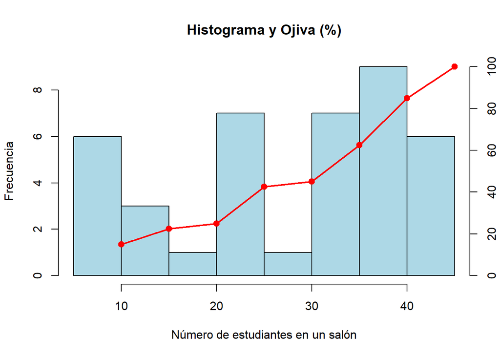

```r
nbreaks <- 10
h <- hist(estudiantes, breaks = nbreaks, plot = FALSE)
hist(estudiantes,
     breaks = nbreaks,
     col = "lightblue",
     main = "Histograma y Ojiva (%)",
     xlab = "Número de estudiantes en un salón",
     ylab = "Frecuencia")
freq_acum_pct <- cumsum(h$counts) / sum(h$counts) * 100
x_vals <- h$breaks[-1]
par(new = TRUE)
plot(x_vals, freq_acum_pct,
     type = "o", pch = 19, lwd = 2, col = "red",
     axes = FALSE, xlab = "", ylab = "",
     xlim = range(h$breaks), ylim = c(0, 100))
axis(4)                           # eje derecho
```

```r
#---- Fin ----
```

## Ejercicio 8.3 Número de autos por familia

### Datos

```r
autos <- c(2, 1, 0, 0, 1, 1, 0, 0, 3, 3, 1, 0, 1, 1, 1, 0, 1, 1, 3, 2, 1, 2, 1, 0, 1, 1, 2, 1, 2, 1, 1, 2, 1, 1, 0, 1, 0, 1, 0, 0, 1, 1, 1, 2, 0, 0, 1, 0, 1, 2, 2, 0, 0, 1, 1, 0, 1, 0, 1, 0, 1, 1, 2, 2, 1, 2, 1, 0, 0, 0, 0, 0, 3, 3, 1)
```

### Procesamiento de datos (Ordenar)

Primero obtenemos un resumen de los datos generados

```r
summary(autos)
```

```
##    Min. 1st Qu.  Median    Mean 3rd Qu.    Max.
##  0.0000  0.0000  1.0000  0.9733  1.0000  3.0000
```

Al ser variables de tipo cuantitativa discretas se pueden ordenar.

### Frecuencias (Clasificar)

Obtenemos las frecuencias de los datos.

```r
(autos) #Datos
```

```
##  [1] 2 1 0 0 1 1 0 0 3 3 1 0 1 1 1 0 1 1 3 2 1 2 1 0 1 1 2 1 2 1 1 2 1 1 0 1 0 1
## [39] 0 0 1 1 1 2 0 0 1 0 1 2 2 0 0 1 1 0 1 0 1 0 1 1 2 2 1 2 1 0 0 0 0 0 3 3 1
```

```r
autos_ord<- sort(autos) #Datos ordenados por clase
(autos_ord)
```

```
##  [1] 0 0 0 0 0 0 0 0 0 0 0 0 0 0 0 0 0 0 0 0 0 0 0 0 1 1 1 1 1 1 1 1 1 1 1 1 1 1
## [39] 1 1 1 1 1 1 1 1 1 1 1 1 1 1 1 1 1 1 1 1 2 2 2 2 2 2 2 2 2 2 2 2 3 3 3 3 3
```

```r
contador <- table(autos) #Frecuencia de los datos
(contador)
```

```
## autos
##  0  1  2  3
## 24 34 12  5
```

```r
cte<- 9
```

### Proporciones

Obtenemos las proporciones.

```r
prop.table(table(autos)) #Proporciones
```

```
## autos
##          0          1          2          3
## 0.32000000 0.45333333 0.16000000 0.06666667
```

### Medidas de tendencia central

#### Moda

Obtenemos la moda

```r
# Función para detectar modalidad
max_frecuencia <- max(contador)
modas <- names(contador)[contador == max_frecuencia]

# Identificar e imprimir resultado
if(length(modas) == 1) {
  cat("UNIMODAL - Moda:", modas)
} else if(length(modas) == 2) {
  cat("BIMODAL - Modas:", paste(modas, collapse = " y "))
} else {
  cat("Hay más de dos clases con mayor frecuencia por lo tanto no hay moda")
}
```

```
## UNIMODAL - Moda: 1
```

#### Mediana

Obtenemos la mediana

```r
  # Calcular mediana
  mediana<- median(autos)
  cat("La mediana es:", mediana, "\n")
```

```
## La mediana es: 1
```

#### Media

Obtenemos la media

```r
media<-mean(autos)
cat("La media es:", media, "\n")
```

```
## La media es: 0.9733333
```

### Medidas de localización

#### Cuartiles

```r
cuantiles <- quantile(autos_ord); (cuantiles)
```

```
##   0%  25%  50%  75% 100%
##    0    0    1    1    3
```

```r
Q1 <- cuantiles[2]; (Q1)
```

```
## 25%
##   0
```

```r
Q2 <- cuantiles[3]; (Q2)
```

```
## 50%
##   1
```

```r
Q3 <- cuantiles[4]; (Q3)
```

```
## 75%
##   1
```

Calculemos el valor máximo y el valor mínimo para los datos

```r
mi_min <- min(autos);
(mi_min)
```

```
## [1] 0
```

```r
mi_max <- max(autos);
(mi_max)
```

```
## [1] 3
```

### Diagrama de caja y brazos

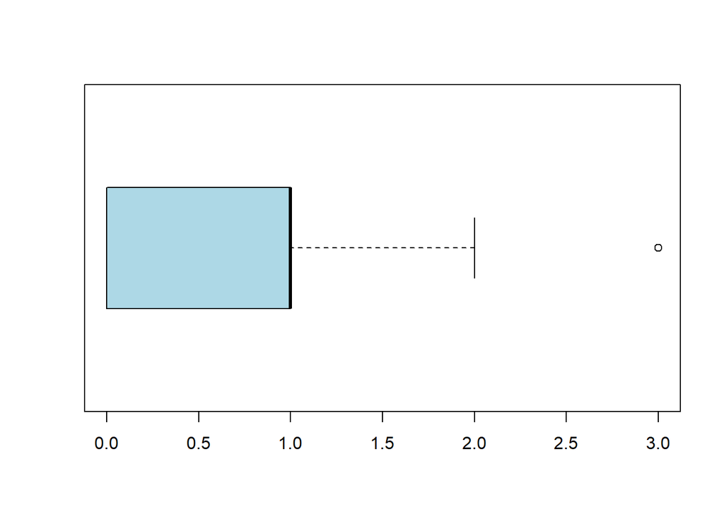

```r
boxplot(autos_ord, horizontal = TRUE, col = "lightblue")
```

### Medidas de dispersión

#### Varianza

```r
varianza <- var(autos); (varianza)
```

```
## [1] 0.756036
```

#### Desviación estándar

```r
DesvEst <- sd(autos); (DesvEst)
```

```
## [1] 0.8695033
```

### Gráficos

Comenzamos a graficar.

#### Gráfica con el comando *barplot*

Generemos la gráfica de barras.

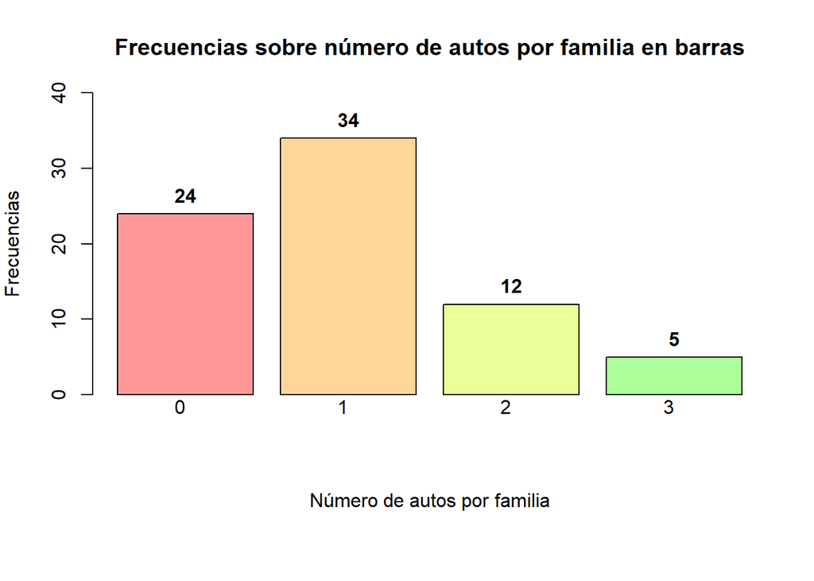

```r
par(mar=c(8,4,4,2))
gb<-barplot(contador, col=rainbow(10,0.4),
        main="Frecuencias sobre número de autos por familia en barras",
        xlab="",
        names.arg="",
        ylab="Frecuencias",
        ylim=c(0,40),
        )
title(xlab="Número de autos por familia",line=4)

#Etiquetas rotadas
text(x=gb,
     y=par("usr")[3]-1.5,
     labels=names(contador),
     srt=0,
     adj=1,
     xpd=TRUE,
     cex=1)

# Agregar valores encima de cada barra
text(x=gb,
     y=contador,
     labels=contador,
     pos=3,
     cex=1,
     font=2)
```

#### Gráfica de porcentajes

Generamos la gráfica de porcentajes.

```r
par(mar=c(8,4,4,2))
tabla <- table(autos); (tabla)
```

```
## autos
##  0  1  2  3
## 24 34 12  5
```

```r
porcentajes <-  round(prop.table(tabla)* 100, 1); (porcentajes)
```

```
## autos
##    0    1    2    3
## 32.0 45.3 16.0  6.7
```

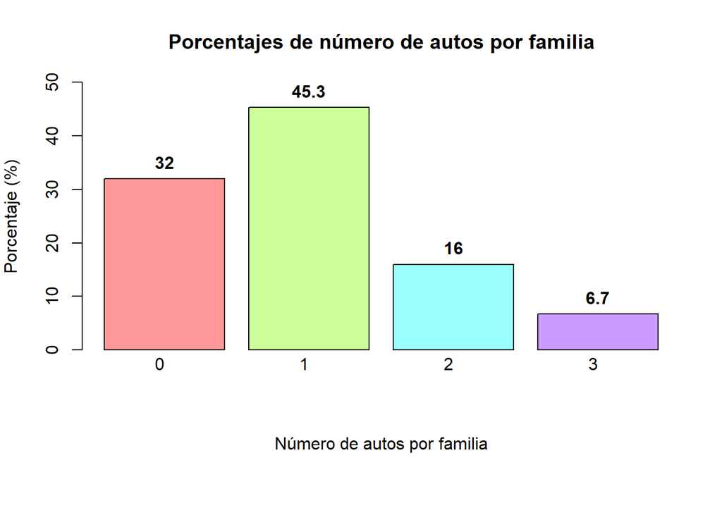

```r
gp<- barplot(porcentajes, col = rainbow(length(tabla),0.4),
    main = "Porcentajes de número de autos por familia",
    xlab = "",
    names.arg="",
    ylab="Porcentaje (%)",
    ylim=c(0,50),
        )

title(xlab="Número de autos por familia",line=4)

#Etiquetas rotadas
text(x=gb,
     y=par("usr")[3]-2.5,
     labels=names(contador),
     srt=0,
     adj=1,
     xpd=TRUE,
     cex=1)

# Agregar valores encima de cada barra
text(x=gp,
     y=porcentajes,
     labels=porcentajes,
     pos=3,
     cex=1,
     font=2)
```

#### Gráfica de pasteles

Generamos la gráfica de pasteles.

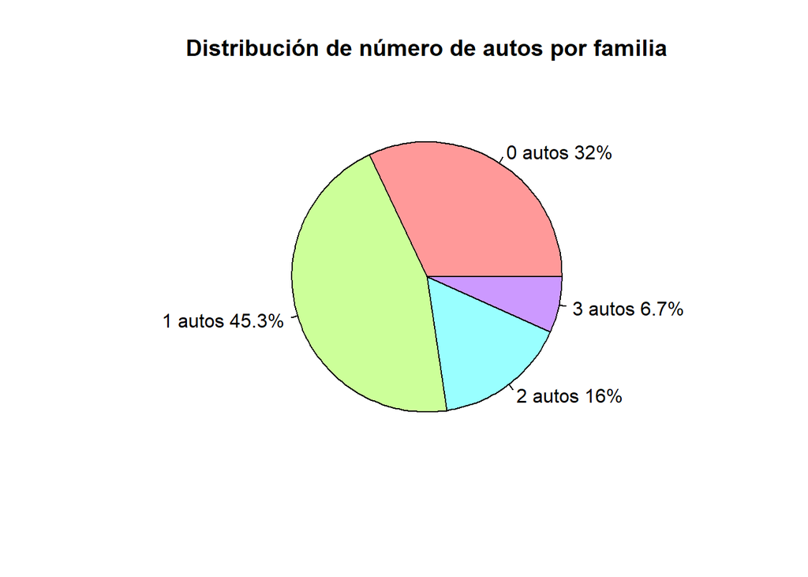

```r
pie(tabla,
    main = "Distribución de número de autos por familia",
    col = rainbow(length(tabla),0.4),
    labels = paste0(names(tabla)," autos ",porcentajes, "%"))
```

#### Gráfica de ojiva

Generamos la gráfica de ojiva

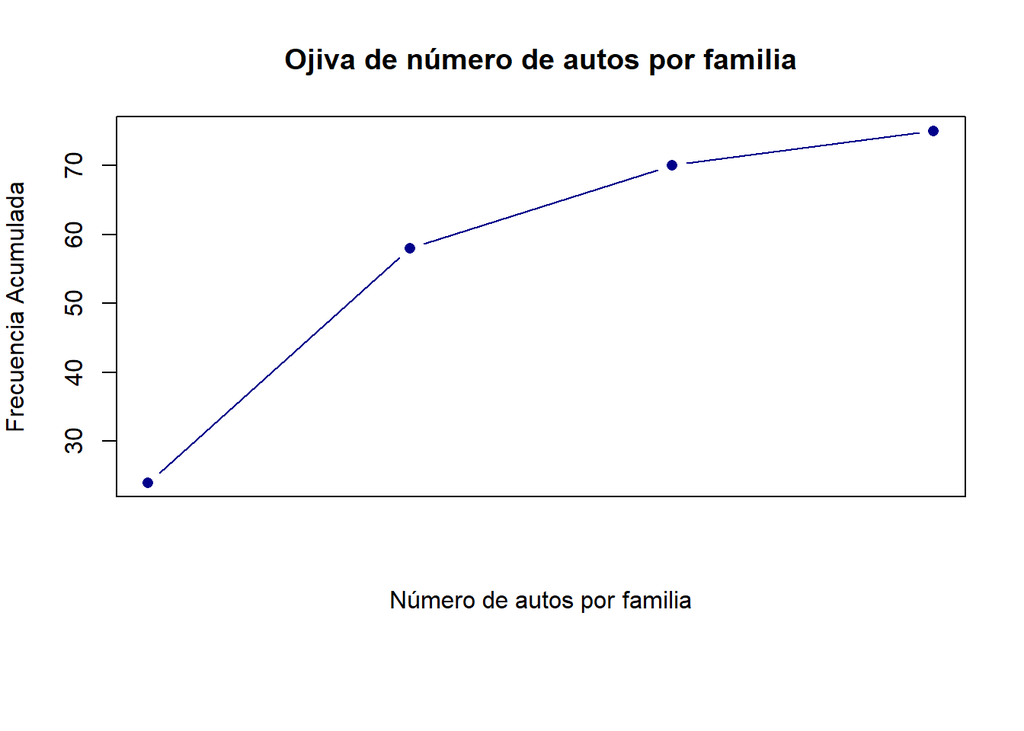

```r
par(mar=c(8,4,4,2))
frec_acum <- cumsum(table(factor(autos)))
plot(frec_acum, type = "b", pch = 16, col = "darkblue",
     main = "Ojiva de número de autos por familia",
     xlab = "Número de autos por familia",
     ylab = "Frecuencia Acumulada",
     xaxt = "n")
```

#### Gráfica de dispersión

```r
indices <- 1:10; (indices)
```

```
##  [1]  1  2  3  4  5  6  7  8  9 10
```

```r
t <- cte*indices; (t)
```

```
##  [1]  9 18 27 36 45 54 63 72 81 90
```

```r
mis_deciles <- autos_ord[t]; (mis_deciles)
```

```
##  [1]  0  0  1  1  1  1  2  3 NA NA
```

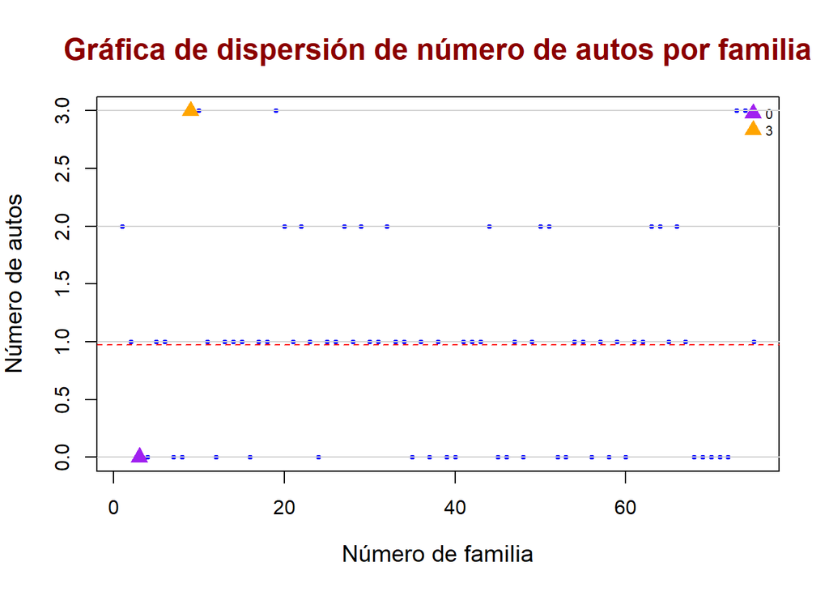

```r
plot(autos,
  main = "Gráfica de dispersión de número de autos por familia",
  xlab = "Número de familia",
  ylab = "Número de autos",
  col = "blue",
  pch = 19,
  cex = 0.5,
  cex.main = 1.5,
  cex.lab = 1.2,
  col.main = "darkred")
legend(
  "topright",                  # ubicación
  legend = c(mi_min,mi_max),    # etiquetas
  pch = 17,
  col=c("purple","orange"),
  pt.cex = 1.5,                # tamaño de los símbolos
  cex = 0.7,
  bty = "n"                    # sin borde en la caja
)
abline(h = media, col = "red", lwd = 1, lty = 2)
abline(h = Q2, col = "lightgreen", lwd = 1, lty = 3)
abline(h = mis_deciles, col = "lightgray", lty = 1.5)
points(which.min(autos), min(autos), col = "purple", pch = 17, cex = 1.5)
points(which.max(autos), max(autos), col = "orange", pch = 17, cex = 1.5)
```

#### Gráfica combinada

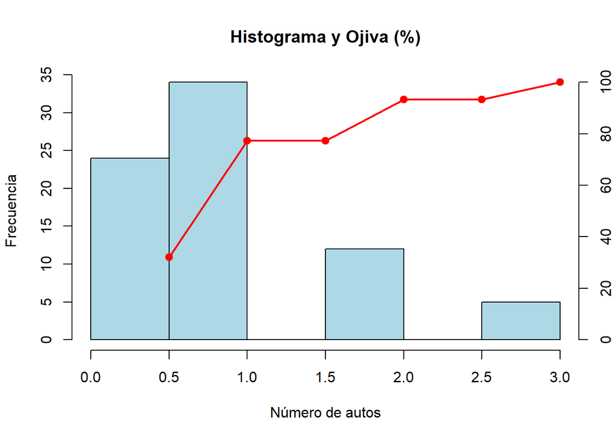

```r
nbreaks <- 10
h <- hist(autos, breaks = nbreaks, plot = FALSE)
hist(autos,
     breaks = nbreaks,
     col = "lightblue",
     main = "Histograma y Ojiva (%)",
     xlab = "Número de autos",
     ylab = "Frecuencia")
freq_acum_pct <- cumsum(h$counts) / sum(h$counts) * 100
x_vals <- h$breaks[-1]
par(new = TRUE)
plot(x_vals, freq_acum_pct,
     type = "o", pch = 19, lwd = 2, col = "red",
     axes = FALSE, xlab = "", ylab = "",
     xlim = range(h$breaks), ylim = c(0, 100))
axis(4)                           # eje derecho
```

```r
#---- Fin ----
```

## Ejercicio 8.4 Goles en un partido

### Datos

```r
goles <- c(0, 1, 1, 0, 0, 1, 2, 0, 4, 0, 0, 0, 3, 0, 2, 3, 1, 1, 0, 1, 3, 0, 0,
4, 0, 1, 0, 4, 3, 3, 1, 2, 0, 0, 4, 4, 1, 2, 0, 0, 1, 0, 0, 4, 1, 3, 1, 0, 1, 0, 0, 3, 0, 0, 0, 0, 0, 0, 3, 4, 3, 1, 1, 0, 0, 3, 0, 1, 1, 0, 1, 0, 1, 1, 0, 3, 0, 1, 3, 0, 0, 3, 1, 3, 1, 3, 0, 1, 2, 0, 1, 1, 3, 0, 1, 0, 0, 1, 1, 2)
```

### Procesamiento de datos (Ordenar)

Primero obtenemos un resumen de los datos generados

```r
summary(goles)
```

```
##    Min. 1st Qu.  Median    Mean 3rd Qu.    Max.
##    0.00    0.00    1.00    1.17    2.00    4.00
```

Al ser variables de tipo cuantitativa discretas se pueden ordenar.

### Frecuencias (Clasificar)

Obtenemos las frecuencias de los datos.

```r
(autos) #Datos
```

```
##  [1] 2 1 0 0 1 1 0 0 3 3 1 0 1 1 1 0 1 1 3 2 1 2 1 0 1 1 2 1 2 1 1 2 1 1 0 1 0 1
## [39] 0 0 1 1 1 2 0 0 1 0 1 2 2 0 0 1 1 0 1 0 1 0 1 1 2 2 1 2 1 0 0 0 0 0 3 3 1
```

```r
goles_ord<- sort(goles) #Datos ordenados por clase
(goles_ord)
```

```
##   [1] 0 0 0 0 0 0 0 0 0 0 0 0 0 0 0 0 0 0 0 0 0 0 0 0 0 0 0 0 0 0 0 0 0 0 0 0 0
##  [38] 0 0 0 0 0 1 1 1 1 1 1 1 1 1 1 1 1 1 1 1 1 1 1 1 1 1 1 1 1 1 1 1 1 1 2 2 2
##  [75] 2 2 2 3 3 3 3 3 3 3 3 3 3 3 3 3 3 3 3 4 4 4 4 4 4 4
```

```r
contador <- table(goles) #Frecuencia de los datos
(contador)
```

```
## goles
##  0  1  2  3  4
## 42 29  6 16  7
```

```r
cte<- 9
```

### Proporciones

Obtenemos las proporciones.

```r
prop.table(table(goles)) #Proporciones
```

```
## goles
##    0    1    2    3    4
## 0.42 0.29 0.06 0.16 0.07
```

### Medidas de tendencia central

#### Moda

Obtenemos la moda

```r
# Función para detectar modalidad
max_frecuencia <- max(contador)
modas <- names(contador)[contador == max_frecuencia]

# Identificar e imprimir resultado
if(length(modas) == 1) {
  cat("UNIMODAL - Moda:", modas)
} else if(length(modas) == 2) {
  cat("BIMODAL - Modas:", paste(modas, collapse = " y "))
} else {
  cat("Hay más de dos clases con mayor frecuencia por lo tanto no hay moda")
}
```

```
## UNIMODAL - Moda: 0
```

#### Mediana

Obtenemos la mediana

```r
  # Calcular mediana
  mediana<- median(goles)
  cat("La mediana es:", mediana, "\n")
```

```
## La mediana es: 1
```

#### Media

Obtenemos la media

```r
media<-mean(goles)
cat("La media es:", media, "\n")
```

```
## La media es: 1.17
```

### Medidas de localización

#### Cuartiles

```r
cuantiles <- quantile(goles_ord); (cuantiles)
```

```
##   0%  25%  50%  75% 100%
##    0    0    1    2    4
```

```r
Q1 <- cuantiles[2]; (Q1)
```

```
## 25%
##   0
```

```r
Q2 <- cuantiles[3]; (Q2)
```

```
## 50%
##   1
```

```r
Q3 <- cuantiles[4]; (Q3)
```

```
## 75%
##   2
```

Calculemos el valor máximo y el valor mínimo para los datos

```r
mi_min <- min(goles);
(mi_min)
```

```
## [1] 0
```

```r
mi_max <- max(goles);
(mi_max)
```

```
## [1] 4
```

### Diagrama de caja y brazos

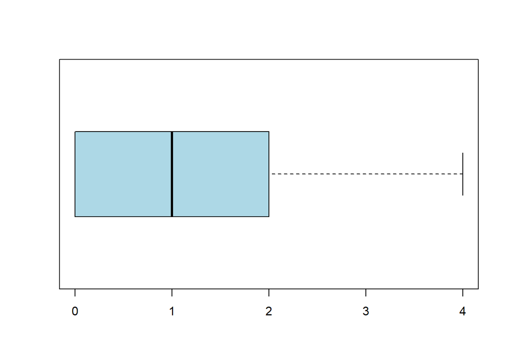

```r
boxplot(goles_ord, horizontal = TRUE, col = "lightblue")
```

### Medidas de dispersión

#### Varianza

```r
varianza <- var(goles); (varianza)
```

```
## [1] 1.738485
```

#### Desviación estándar

```r
DesvEst <- sd(goles); (DesvEst)
```

```
## [1] 1.318516
```

### Gráficos

Comenzamos a graficar.

#### Gráfica con el comando *barplot*

Generemos la gráfica de barras.

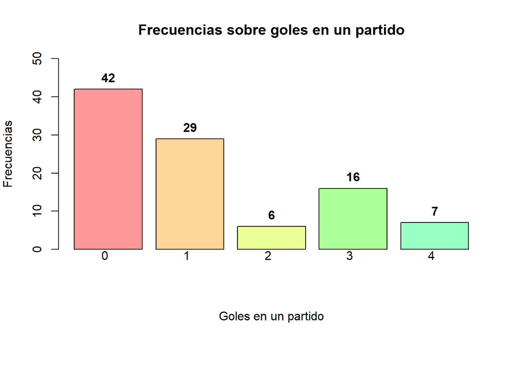

```r
par(mar=c(8,4,4,2))
gb<-barplot(contador, col=rainbow(10,0.4),
        main="Frecuencias sobre goles en un partido",
        xlab="",
        names.arg="",
        ylab="Frecuencias",
        ylim=c(0,50),
        )
title(xlab="Goles en un partido",line=4)

#Etiquetas rotadas
text(x=gb,
     y=par("usr")[3]-1.5,
     labels=names(contador),
     srt=0,
     adj=1,
     xpd=TRUE,
     cex=1)

# Agregar valores encima de cada barra
text(x=gb,
     y=contador,
     labels=contador,
     pos=3,
     cex=1,
     font=2)
```

#### Gráfica de porcentajes

Generamos la gráfica de porcentajes.

```r
par(mar=c(8,4,4,2))
tabla <- table(goles); (tabla)
```

```
## goles
##  0  1  2  3  4
## 42 29  6 16  7
```

```r
porcentajes <-  round(prop.table(tabla)* 100, 1); (porcentajes)
```

```
## goles
##  0  1  2  3  4
## 42 29  6 16  7
```

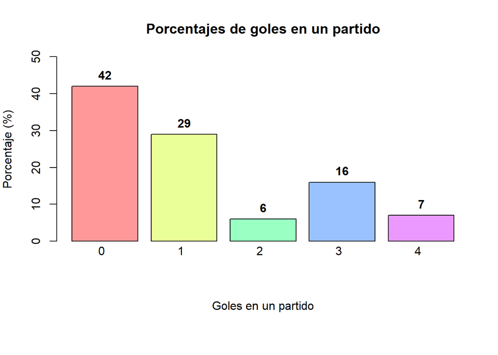

```r
gp<- barplot(porcentajes, col = rainbow(length(tabla),0.4),
    main = "Porcentajes de goles en un partido",
    xlab = "",
    names.arg="",
    ylab="Porcentaje (%)",
    ylim=c(0,50),
        )

title(xlab="Goles en un partido",line=4)

#Etiquetas rotadas
text(x=gb,
     y=par("usr")[3]-2.5,
     labels=names(contador),
     srt=0,
     adj=1,
     xpd=TRUE,
     cex=1)

# Agregar valores encima de cada barra
text(x=gp,
     y=porcentajes,
     labels=porcentajes,
     pos=3,
     cex=1,
     font=2)
```

#### Gráfica de pasteles

Generamos la gráfica de pasteles.

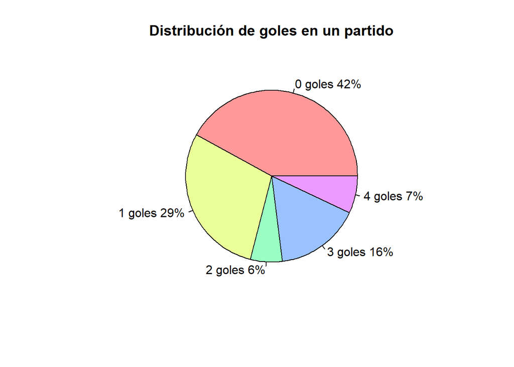

```r
pie(tabla,
    main = "Distribución de goles en un partido",
    col = rainbow(length(tabla),0.4),
    labels = paste0(names(tabla)," goles ",porcentajes, "%"))
```

#### Gráfica de ojiva

Generamos la gráfica de ojiva

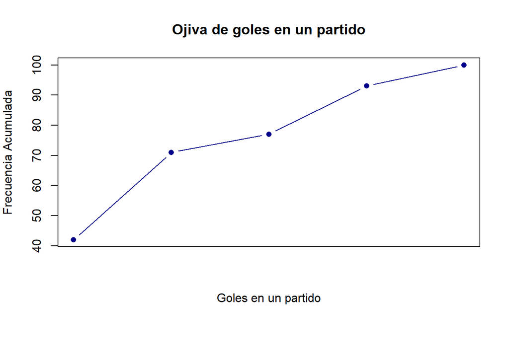

```r
par(mar=c(8,4,4,2))
frec_acum <- cumsum(table(factor(goles)))
plot(frec_acum, type = "b", pch = 16, col = "darkblue",
     main = "Ojiva de goles en un partido",
     xlab = "Goles en un partido",
     ylab = "Frecuencia Acumulada",
     xaxt = "n")
```

#### Gráfica de dispersión

```r
indices <- 1:10; (indices)
```

```
##  [1]  1  2  3  4  5  6  7  8  9 10
```

```r
t <- cte*indices; (t)
```

```
##  [1]  9 18 27 36 45 54 63 72 81 90
```

```r
mis_deciles <- goles_ord[t]; (mis_deciles)
```

```
##  [1] 0 0 0 0 1 1 1 2 3 3
```

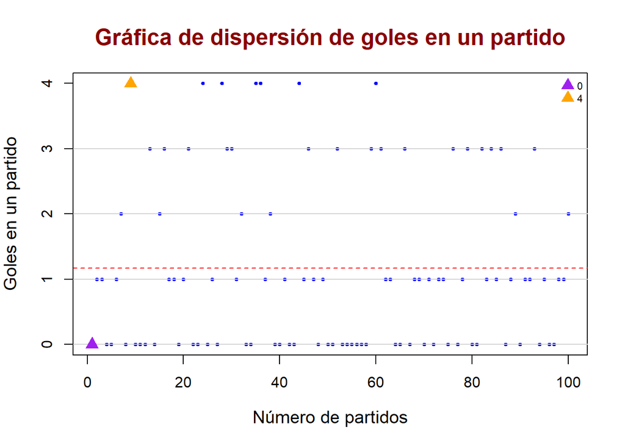

```r
plot(
  goles,
  main = "Gráfica de dispersión de goles en un partido",
  xlab = "Número de partidos",
  ylab = "Goles en un partido",
  col = "blue",
  pch = 19,
  cex = 0.5,
  cex.main = 1.5,
  cex.lab = 1.2,
  col.main = "darkred")
legend(
  "topright",                  # ubicación
  legend = c(mi_min,mi_max),    # etiquetas
  pch = 17,
  col=c("purple","orange"),
  pt.cex = 1.5,                # tamaño de los símbolos
  cex = 0.7,
  bty = "n"                    # sin borde en la caja
)
abline(h = media, col = "red", lwd = 1, lty = 2)
abline(h = Q2, col = "lightgreen", lwd = 1, lty = 3)
abline(h = mis_deciles, col = "lightgray", lty = 1.5)
points(which.min(goles), min(goles), col = "purple", pch = 17, cex = 1.5)
points(which.max(goles), max(goles), col = "orange", pch = 17, cex = 1.5)
```

#### Gráfica combinada

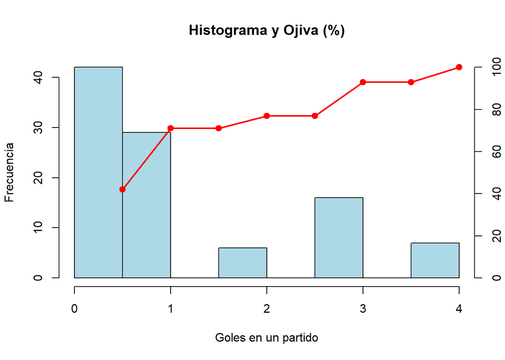

```r
nbreaks <- 10
h <- hist(goles, breaks = nbreaks, plot = FALSE)
hist(goles,
     breaks = nbreaks,
     col = "lightblue",
     main = "Histograma y Ojiva (%)",
     xlab = "Goles en un partido",
     ylab = "Frecuencia")
freq_acum_pct <- cumsum(h$counts) / sum(h$counts) * 100
x_vals <- h$breaks[-1]
par(new = TRUE)
plot(x_vals, freq_acum_pct,
     type = "o", pch = 19, lwd = 2, col = "red",
     axes = FALSE, xlab = "", ylab = "",
     xlim = range(h$breaks), ylim = c(0, 100))
axis(4)                           # eje derecho
```

```r
#---- Fin ----
```

## Ejercicio 8.5 Accidentes en una vialidad

### Datos

```r
accidentes<- c(22, 24, 35, 8, 12, 33, 17, 31, 24, 12, 6, 14, 26, 8, 41, 3, 15, 7, 3, 23, 10, 17, 3, 7, 1, 11, 19, 4, 33, 7, 10, 2, 2, 19, 1, 15, 7, 16, 13, 3, 26, 4, 16, 18, 27, 18, 17, 32, 25, 22, 34, 40, 47, 35, 19, 27, 12, 44, 37, 27, 40, 18, 28, 16, 31, 37, 32, 44, 29, 35, 25, 28, 27, 31, 33, 21, 41, 20, 39, 28, 22, 34, 27, 28, 37, 26, 29, 37, 38, 26, 38, 53, 39, 41, 35, 57, 27, 41, 41, 72, 53, 64, 67, 46, 44, 31, 47, 56, 56, 63, 47, 58, 44, 32, 70, 53, 59, 51, 70, 44, 51, 52, 46, 44, 46, 41, 54, 63, 46, 47, 37, 60, 34, 49, 63, 42, 48, 44, 65, 63, 45, 63, 42, 58, 43, 54, 90, 55, 57, 54, 55, 46, 46, 46, 55, 23, 39, 35, 44, 58, 68, 44, 11, 23, 24, 13, 47, 49)
```

### Procesamiento de datos (Ordenar)

Primero obtenemos un resumen de los datos generados

```r
summary(accidentes)
```

```
##    Min. 1st Qu.  Median    Mean 3rd Qu.    Max.
##    1.00   20.75   35.00   34.40   46.25   90.00
```

Al ser variables de tipo cuantitativa discretas se pueden ordenar.

### Frecuencias (Clasificar)

Obtenemos las frecuencias de los datos.

```r
(accidentes) #Datos
```

```
##   [1] 22 24 35  8 12 33 17 31 24 12  6 14 26  8 41  3 15  7  3 23 10 17  3  7  1
##  [26] 11 19  4 33  7 10  2  2 19  1 15  7 16 13  3 26  4 16 18 27 18 17 32 25 22
##  [51] 34 40 47 35 19 27 12 44 37 27 40 18 28 16 31 37 32 44 29 35 25 28 27 31 33
##  [76] 21 41 20 39 28 22 34 27 28 37 26 29 37 38 26 38 53 39 41 35 57 27 41 41 72
## [101] 53 64 67 46 44 31 47 56 56 63 47 58 44 32 70 53 59 51 70 44 51 52 46 44 46
## [126] 41 54 63 46 47 37 60 34 49 63 42 48 44 65 63 45 63 42 58 43 54 90 55 57 54
## [151] 55 46 46 46 55 23 39 35 44 58 68 44 11 23 24 13 47 49
```

```r
accidentes_ord<- sort(accidentes) #Datos ordenados por clase
(accidentes_ord)
```

```
##   [1]  1  1  2  2  3  3  3  3  4  4  6  7  7  7  7  8  8 10 10 11 11 12 12 12 13
##  [26] 13 14 15 15 16 16 16 17 17 17 18 18 18 19 19 19 20 21 22 22 22 23 23 23 24
##  [51] 24 24 25 25 26 26 26 26 27 27 27 27 27 27 28 28 28 28 29 29 31 31 31 31 32
##  [76] 32 32 33 33 33 34 34 34 35 35 35 35 35 37 37 37 37 37 38 38 39 39 39 40 40
## [101] 41 41 41 41 41 41 42 42 43 44 44 44 44 44 44 44 44 44 45 46 46 46 46 46 46
## [126] 46 47 47 47 47 47 48 49 49 51 51 52 53 53 53 54 54 54 55 55 55 56 56 57 57
## [151] 58 58 58 59 60 63 63 63 63 63 64 65 67 68 70 70 72 90
```

```r
contador <- table(accidentes) #Frecuencia de los datos
(contador)
```

```
## accidentes
##  1  2  3  4  6  7  8 10 11 12 13 14 15 16 17 18 19 20 21 22 23 24 25 26 27 28
##  2  2  4  2  1  4  2  2  2  3  2  1  2  3  3  3  3  1  1  3  3  3  2  4  6  4
## 29 31 32 33 34 35 37 38 39 40 41 42 43 44 45 46 47 48 49 51 52 53 54 55 56 57
##  2  4  3  3  3  5  5  2  3  2  6  2  1  9  1  7  5  1  2  2  1  3  3  3  2  2
## 58 59 60 63 64 65 67 68 70 72 90
##  3  1  1  5  1  1  1  1  2  1  1
```

```r
cte<- 9
```

### Proporciones

Obtenemos las proporciones.

```r
prop.table(table(accidentes)) #Proporciones
```

```
## accidentes
##           1           2           3           4           6           7
## 0.011904762 0.011904762 0.023809524 0.011904762 0.005952381 0.023809524
##           8          10          11          12          13          14
## 0.011904762 0.011904762 0.011904762 0.017857143 0.011904762 0.005952381
##          15          16          17          18          19          20
## 0.011904762 0.017857143 0.017857143 0.017857143 0.017857143 0.005952381
##          21          22          23          24          25          26
## 0.005952381 0.017857143 0.017857143 0.017857143 0.011904762 0.023809524
##          27          28          29          31          32          33
## 0.035714286 0.023809524 0.011904762 0.023809524 0.017857143 0.017857143
##          34          35          37          38          39          40
## 0.017857143 0.029761905 0.029761905 0.011904762 0.017857143 0.011904762
##          41          42          43          44          45          46
## 0.035714286 0.011904762 0.005952381 0.053571429 0.005952381 0.041666667
##          47          48          49          51          52          53
## 0.029761905 0.005952381 0.011904762 0.011904762 0.005952381 0.017857143
##          54          55          56          57          58          59
## 0.017857143 0.017857143 0.011904762 0.011904762 0.017857143 0.005952381
##          60          63          64          65          67          68
## 0.005952381 0.029761905 0.005952381 0.005952381 0.005952381 0.005952381
##          70          72          90
## 0.011904762 0.005952381 0.005952381
```

### Medidas de tendencia central

#### Moda

Obtenemos la moda

```r
# Función para detectar modalidad
max_frecuencia <- max(contador)
modas <- names(contador)[contador == max_frecuencia]

# Identificar e imprimir resultado
if(length(modas) == 1) {
  cat("UNIMODAL - Moda:", modas)
} else if(length(modas) == 2) {
  cat("BIMODAL - Modas:", paste(modas, collapse = " y "))
} else {
  cat("Hay más de dos clases con mayor frecuencia por lo tanto no hay moda")
}
```

```
## UNIMODAL - Moda: 44
```

#### Mediana

Obtenemos la mediana

```r
  # Calcular mediana
  mediana<- median(accidentes)
  cat("La mediana es:", mediana, "\n")
```

```
## La mediana es: 35
```

#### Media

Obtenemos la media

```r
media<-mean(accidentes)
cat("La media es:", media, "\n")
```

```
## La media es: 34.39881
```

### Medidas de localización

#### Cuartiles

```r
cuantiles <- quantile(accidentes_ord); (cuantiles)
```

```
##    0%   25%   50%   75%  100%
##  1.00 20.75 35.00 46.25 90.00
```

```r
Q1 <- cuantiles[2]; (Q1)
```

```
##   25%
## 20.75
```

```r
Q2 <- cuantiles[3]; (Q2)
```

```
## 50%
##  35
```

```r
Q3 <- cuantiles[4]; (Q3)
```

```
##   75%
## 46.25
```

Calculemos el valor máximo y el valor mínimo para los datos

```r
mi_min <- min(accidentes);
(mi_min)
```

```
## [1] 1
```

```r
mi_max <- max(accidentes);
(mi_max)
```

```
## [1] 90
```

### Diagrama de caja y brazos

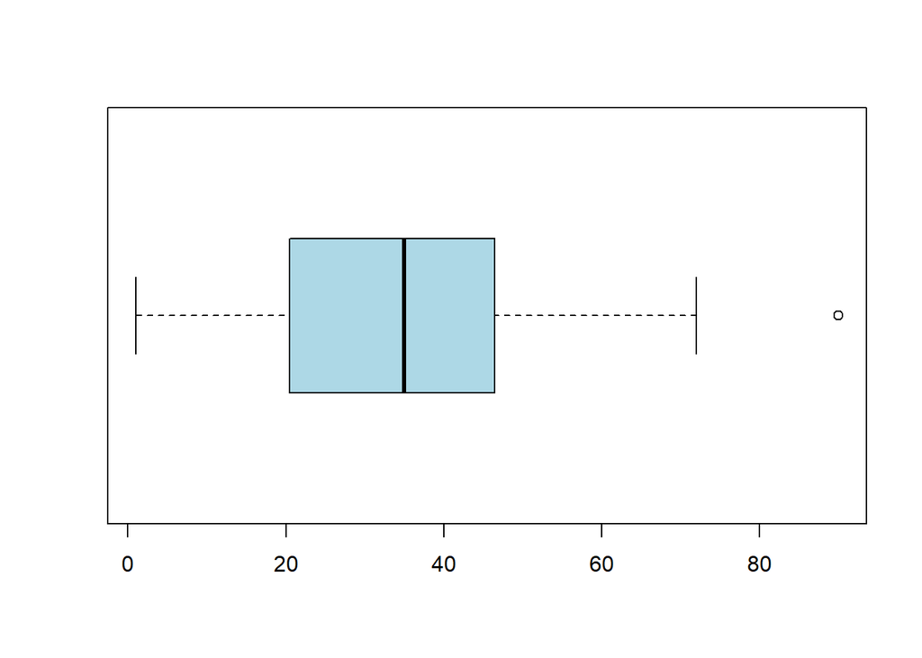

```r
boxplot(accidentes_ord, horizontal = TRUE, col = "lightblue")
```

### Medidas de dispersión

#### Varianza

```r
varianza <- var(accidentes); (varianza)
```

```
## [1] 332.6843
```

#### Desviación estándar

```r
DesvEst <- sd(accidentes); (DesvEst)
```

```
## [1] 18.23964
```

### Gráficos

Comenzamos a graficar.

#### Generemos la gráfica de barras.

```r
# Regla de Sturges lo que nos da el número de intervalos
n <- length(accidentes)
nbreaks <- round(1 + 3.322 * log10(n))
(nbreaks)
```

```
## [1] 8
```

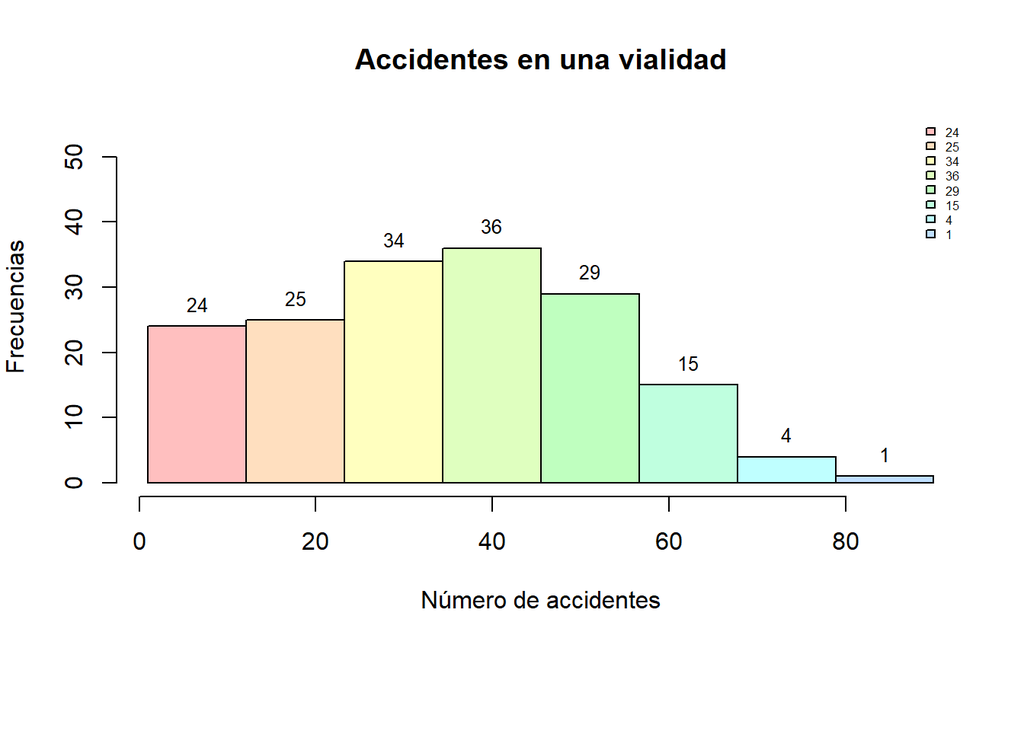

```r
rango <- range(accidentes)
breaks_exactos <- seq(from = rango[1], to = rango[2], length.out = nbreaks + 1)

par(mar=c(8,4,4,2))
miscolores <- rainbow(12,0.25)
gb <- hist(accidentes, breaks = breaks_exactos, plot = FALSE) #histograma simple de los datos
gb2 <- hist(accidentes, breaks = breaks_exactos, col = miscolores,
          main = "Accidentes en una vialidad",
          xlab = "Número de accidentes",
          ylab = "Frecuencias",
          ylim = c(0, max(gb$counts)*1.5))

text(gb2$mids, gb2$counts, labels = gb2$counts, pos = 3, cex = 0.8,
     col = "black")

nl <- length(gb2$counts)
legend(
  "topright",
  legend = gb2$counts,
  fill = miscolores[1:nl],  # Solo los colores necesarios
  pt.cex = 1.5,
  cex = 0.5,
  bty = "n"
)
```

#### Gráfica de porcentajes

Generamos la gráfica de porcentajes.

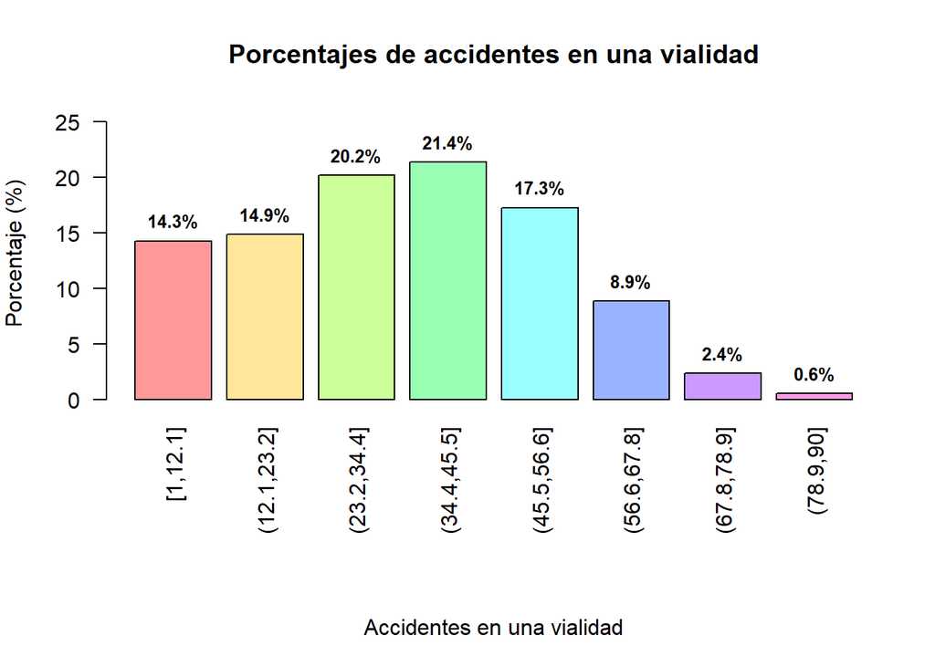

```r
par(mar=c(10,4,4,2))

intervalos <- cut(accidentes, breaks = breaks_exactos, include.lowest = TRUE)
tabla_intervalos <- table(intervalos)
porcentajes_intervalos <- round(prop.table(tabla_intervalos) * 100, 1)
gp <- barplot(porcentajes_intervalos,
                 col = rainbow(length(tabla_intervalos), 0.4),
                 main = "Porcentajes de accidentes en una vialidad",
                 xlab = "",
                 ylab = "Porcentaje (%)",
                 ylim = c(0, max(porcentajes_intervalos) + 5),
                 las = 2)  # Etiquetas verticales

title(xlab = "Accidentes en una vialidad", line = 8)

# Agregar valores encima de barras
text(x = gp,
     y = porcentajes_intervalos,
     labels = paste0(porcentajes_intervalos, "%"),
     pos = 3,
     cex = 0.8,
     font = 2)
```

#### Gráfica de pasteles

Generamos la gráfica de pasteles.

[figure not shown]

```r
par(pin = c(7, 5))
pie(tabla_intervalos,
    main = "Distribución de accidentes en una vialidad",
    col = rainbow(length(tabla_intervalos), 0.7),
    labels = NA,
    cex.main = 1.5)

legend(x =0.78, y = 0.8,
       legend = paste(names(tabla_intervalos), "(", porcentajes, "%)"),
       fill = rainbow(length(tabla_intervalos), 0.7),
       cex = 0.7,
       title = "Intervalos de accidentes",
       title.cex = 0.9)
```

#### Gráfica de ojiva

Generamos la gráfica de ojiva

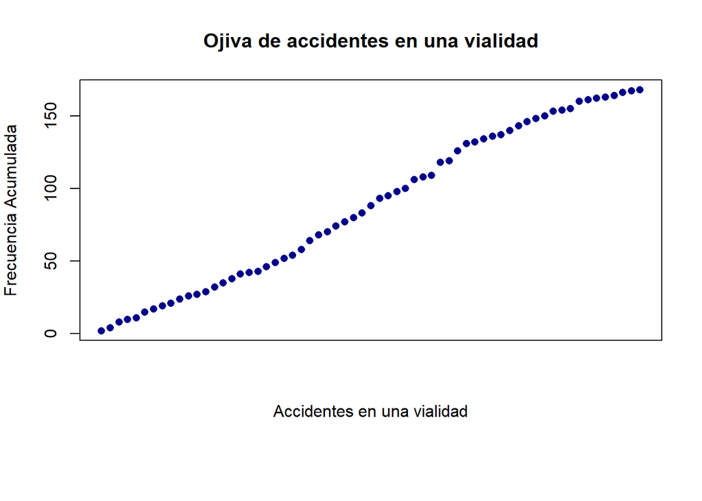

```r
par(mar=c(8,4,4,2))
frec_acum <- cumsum(table(factor(accidentes)))
plot(frec_acum, type = "b", pch = 16, col = "darkblue",
     main = "Ojiva de accidentes en una vialidad",
     xlab = "Accidentes en una vialidad",
     ylab = "Frecuencia Acumulada",
     xaxt = "n")
```

#### Gráfica de dispersión

```r
indices <- 1:10; (indices)
```

```
##  [1]  1  2  3  4  5  6  7  8  9 10
```

```r
t <- cte*indices; (t)
```

```
##  [1]  9 18 27 36 45 54 63 72 81 90
```

```r
mis_deciles <- tabla_intervalos[t]; (mis_deciles)
```

```
## intervalos
## <NA> <NA> <NA> <NA> <NA> <NA> <NA> <NA> <NA> <NA>
##
```

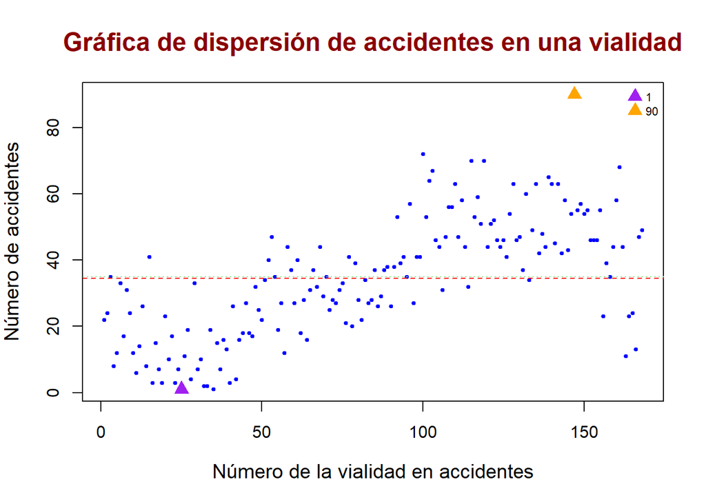

```r
plot(
  accidentes,
  main = "Gráfica de dispersión de accidentes en una vialidad",
  xlab = "Número de la vialidad en accidentes",
  ylab = "Número de accidentes",
  col = "blue",
  pch = 19,
  cex = 0.5,
  cex.main = 1.5,
  cex.lab = 1.2,
  col.main = "darkred")
legend(
  "topright",                  # ubicación
  legend = c(mi_min,mi_max),    # etiquetas
  pch = 17,
  col=c("purple","orange"),
  pt.cex = 1.5,                # tamaño de los símbolos
  cex = 0.7,
  bty = "n"                    # sin borde en la caja
)
abline(h = media, col = "red", lwd = 1, lty = 2)
abline(h = Q2, col = "lightgreen", lwd = 1, lty = 3)
abline(h = mis_deciles, col = "lightgray", lty = 1.5)
points(which.min(accidentes), min(accidentes), col = "purple", pch = 17, cex = 1.5)
points(which.max(accidentes), max(accidentes), col = "orange", pch = 17, cex = 1.5)
```

#### Gráfica combinada

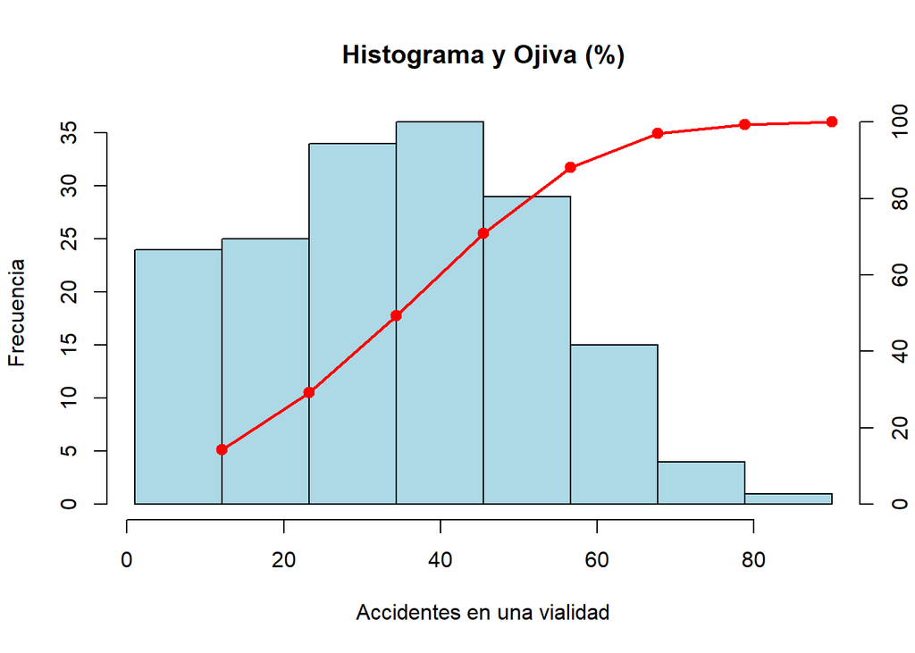

```r
nbreaks <- 10
h <- hist(accidentes, breaks = breaks_exactos, plot = FALSE)
hist(accidentes,
     breaks = breaks_exactos,
     col = "lightblue",
     main = "Histograma y Ojiva (%)",
     xlab = "Accidentes en una vialidad",
     ylab = "Frecuencia")
freq_acum_pct <- cumsum(h$counts) / sum(h$counts) * 100
x_vals <- h$breaks[-1]
par(new = TRUE)
plot(x_vals, freq_acum_pct,
     type = "o", pch = 19, lwd = 2, col = "red",
     axes = FALSE, xlab = "", ylab = "",
     xlim = range(h$breaks), ylim = c(0, 100))
axis(4)                           # eje derecho
```

```r
#---- Fin ----
```

# Ejercicio 9: Variables Cuantitativas Continuas

## Ejercicio 9.1 Estatura en metros

### Datos

```r
estatura<- c(1.57, 1.97, 1.85, 1.78, 1.62, 1.67, 1.92, 1.96, 1.76, 1.94, 1.85, 1.71, 1.65, 1.98, 1.56, 1.84, 1.91, 1.61, 1.8, 1.58, 1.7, 1.62, 1.76, 1.84, 1.95, 1.67, 1.62, 1.65, 1.61, 1.56, 1.63, 1.96, 1.53, 1.75, 1.9, 1.92, 1.79, 1.62, 1.79, 1.57, 1.74, 1.55, 1.65, 1.84, 1.6, 1.7, 1.9, 1.61, 1.54, 1.89, 1.84, 1.76, 1.61, 1.59, 1.81, 1.52, 1.61, 1.91, 1.65, 1.51, 1.98, 1.54, 1.87, 1.92, 1.51, 1.93, 1.78, 1.67, 1.66, 1.82, 1.56, 1.66, 1.79, 1.88, 1.78, 1.84, 1.69, 1.95, 1.99, 1.88, 1.51, 1.76, 1.9, 1.6, 1.69, 1.77, 1.87, 1.67, 1.66, 1.71, 1.64, 1.81, 1.52, 1.8, 1.71, 1.52, 2, 1.81, 1.92, 1.7)
```

### Procesamiento de datos (Ordenar)

Primero obtenemos un resumen de los datos generados

```r
summary(estatura)
```

```
##    Min. 1st Qu.  Median    Mean 3rd Qu.    Max.
##   1.510   1.620   1.745   1.741   1.855   2.000
```

### Frecuencias (Clasificar)

Obtenemos las frecuencias de los datos.

```r
(estatura) #Datos
```

```
##   [1] 1.57 1.97 1.85 1.78 1.62 1.67 1.92 1.96 1.76 1.94 1.85 1.71 1.65 1.98 1.56
##  [16] 1.84 1.91 1.61 1.80 1.58 1.70 1.62 1.76 1.84 1.95 1.67 1.62 1.65 1.61 1.56
##  [31] 1.63 1.96 1.53 1.75 1.90 1.92 1.79 1.62 1.79 1.57 1.74 1.55 1.65 1.84 1.60
##  [46] 1.70 1.90 1.61 1.54 1.89 1.84 1.76 1.61 1.59 1.81 1.52 1.61 1.91 1.65 1.51
##  [61] 1.98 1.54 1.87 1.92 1.51 1.93 1.78 1.67 1.66 1.82 1.56 1.66 1.79 1.88 1.78
##  [76] 1.84 1.69 1.95 1.99 1.88 1.51 1.76 1.90 1.60 1.69 1.77 1.87 1.67 1.66 1.71
##  [91] 1.64 1.81 1.52 1.80 1.71 1.52 2.00 1.81 1.92 1.70
```

```r
estatura_ord<- sort(estatura) #Datos ordenados por clase
(estatura_ord)
```

```
##   [1] 1.51 1.51 1.51 1.52 1.52 1.52 1.53 1.54 1.54 1.55 1.56 1.56 1.56 1.57 1.57
##  [16] 1.58 1.59 1.60 1.60 1.61 1.61 1.61 1.61 1.61 1.62 1.62 1.62 1.62 1.63 1.64
##  [31] 1.65 1.65 1.65 1.65 1.66 1.66 1.66 1.67 1.67 1.67 1.67 1.69 1.69 1.70 1.70
##  [46] 1.70 1.71 1.71 1.71 1.74 1.75 1.76 1.76 1.76 1.76 1.77 1.78 1.78 1.78 1.79
##  [61] 1.79 1.79 1.80 1.80 1.81 1.81 1.81 1.82 1.84 1.84 1.84 1.84 1.84 1.85 1.85
##  [76] 1.87 1.87 1.88 1.88 1.89 1.90 1.90 1.90 1.91 1.91 1.92 1.92 1.92 1.92 1.93
##  [91] 1.94 1.95 1.95 1.96 1.96 1.97 1.98 1.98 1.99 2.00
```

```r
contador <- table(estatura) #Frecuencia de los datos
(contador)
```

```
## estatura
## 1.51 1.52 1.53 1.54 1.55 1.56 1.57 1.58 1.59  1.6 1.61 1.62 1.63 1.64 1.65 1.66
##    3    3    1    2    1    3    2    1    1    2    5    4    1    1    4    3
## 1.67 1.69  1.7 1.71 1.74 1.75 1.76 1.77 1.78 1.79  1.8 1.81 1.82 1.84 1.85 1.87
##    4    2    3    3    1    1    4    1    3    3    2    3    1    5    2    2
## 1.88 1.89  1.9 1.91 1.92 1.93 1.94 1.95 1.96 1.97 1.98 1.99    2
##    2    1    3    2    4    1    1    2    2    1    2    1    1
```

```r
cte<- 9
```

### Proporciones

Obtenemos las proporciones.

```r
prop.table(table(estatura)) #Proporciones
```

```
## estatura
## 1.51 1.52 1.53 1.54 1.55 1.56 1.57 1.58 1.59  1.6 1.61 1.62 1.63 1.64 1.65 1.66
## 0.03 0.03 0.01 0.02 0.01 0.03 0.02 0.01 0.01 0.02 0.05 0.04 0.01 0.01 0.04 0.03
## 1.67 1.69  1.7 1.71 1.74 1.75 1.76 1.77 1.78 1.79  1.8 1.81 1.82 1.84 1.85 1.87
## 0.04 0.02 0.03 0.03 0.01 0.01 0.04 0.01 0.03 0.03 0.02 0.03 0.01 0.05 0.02 0.02
## 1.88 1.89  1.9 1.91 1.92 1.93 1.94 1.95 1.96 1.97 1.98 1.99    2
## 0.02 0.01 0.03 0.02 0.04 0.01 0.01 0.02 0.02 0.01 0.02 0.01 0.01
```

### Medidas de tendencia central

#### Moda

Obtenemos la moda

```r
# Función para detectar modalidad
max_frecuencia <- max(contador)
modas <- names(contador)[contador == max_frecuencia]

# Identificar e imprimir resultado
if(length(modas) == 1) {
  cat("UNIMODAL - Moda:", modas)
} else if(length(modas) == 2) {
  cat("BIMODAL - Modas:", paste(modas, collapse = " y "))
} else {
  cat("Hay más de dos clases con mayor frecuencia por lo tanto no hay moda")
}
```

```
## BIMODAL - Modas: 1.61 y 1.84
```

#### Mediana

Obtenemos la mediana

```r
  # Calcular mediana
  mediana<- median(estatura)
  cat("La mediana es:", mediana, "\n")
```

```
## La mediana es: 1.745
```

#### Media

Obtenemos la media

```r
media<-mean(estatura)
cat("La media es:", media, "\n")
```

```
## La media es: 1.7407
```

### Medidas de localización

#### Cuartiles

```r
cuantiles <- quantile(estatura_ord); (cuantiles)
```

```
##    0%   25%   50%   75%  100%
## 1.510 1.620 1.745 1.855 2.000
```

```r
Q1 <- cuantiles[2]; (Q1)
```

```
##  25%
## 1.62
```

```r
Q2 <- cuantiles[3]; (Q2)
```

```
##   50%
## 1.745
```

```r
Q3 <- cuantiles[4]; (Q3)
```

```
##   75%
## 1.855
```

Calculemos el valor máximo y el valor mínimo para los datos

```r
mi_min <- min(estatura);
(mi_min)
```

```
## [1] 1.51
```

```r
mi_max <- max(estatura);
(mi_max)
```

```
## [1] 2
```

### Diagrama de caja y brazos

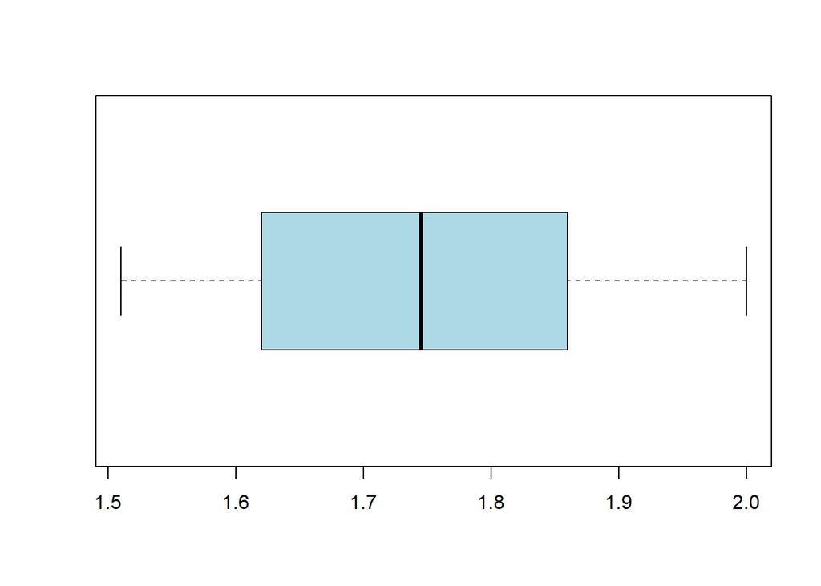

```r
boxplot(estatura_ord, horizontal = TRUE, col = "lightblue")
```

### Medidas de dispersión

#### Varianza

```r
varianza <- var(estatura); (varianza)
```

```
## [1] 0.02010759
```

#### Desviación estándar

```r
DesvEst <- sd(estatura); (DesvEst)
```

```
## [1] 0.1418012
```

### Gráficos

Comenzamos a graficar.

#### Generemos la gráfica de barras.

```r
# Regla de Sturges lo que nos da el número de intervalos
n <- length(estatura)
nbreaks <- round(1 + 3.322 * log10(n))
(nbreaks)
```

```
## [1] 8
```

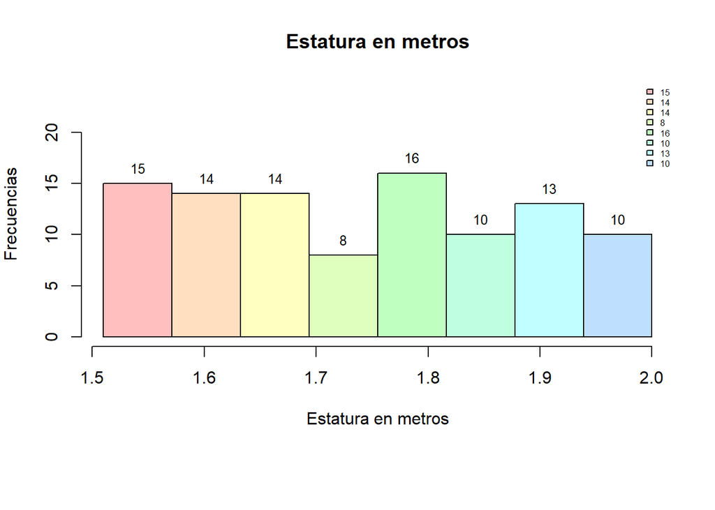

```r
rango <- range(estatura)
breaks_exactos <- seq(from = rango[1], to = rango[2], length.out = nbreaks + 1)

par(mar=c(8,4,4,2))
miscolores <- rainbow(12,0.25)
gb <- hist(estatura, breaks = breaks_exactos, plot = FALSE) #histograma simple de los datos
gb2 <- hist(estatura, breaks = breaks_exactos, col = miscolores,
          main = "Estatura en metros",
          xlab = "Estatura en metros",
          ylab = "Frecuencias",
          ylim = c(0, max(gb$counts)*1.5))

text(gb2$mids, gb2$counts, labels = gb2$counts, pos = 3, cex = 0.8,
     col = "black")

nl <- length(gb2$counts)
legend(
  "topright",
  legend = gb2$counts,
  fill = miscolores[1:nl],  # Solo los colores necesarios
  pt.cex = 1.5,
  cex = 0.5,
  bty = "n"
)
```

#### Gráfica de porcentajes

Generamos la gráfica de porcentajes.

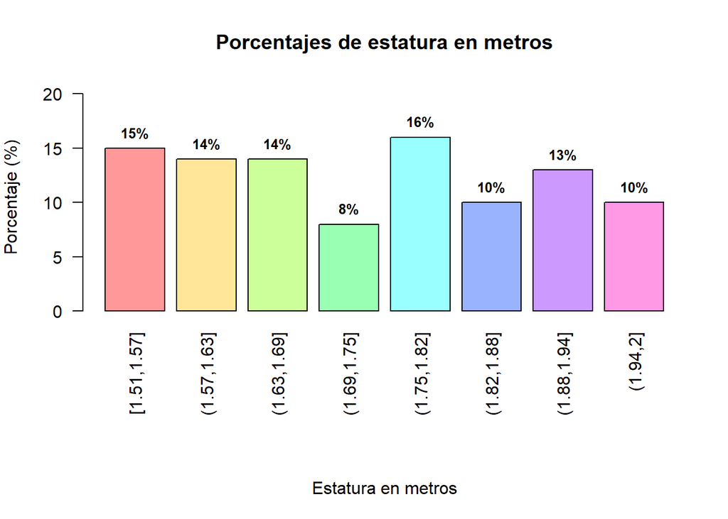

```r
par(mar=c(10,4,4,2))

intervalos <- cut(estatura, breaks = breaks_exactos, include.lowest = TRUE)
tabla_intervalos <- table(intervalos)
porcentajes_intervalos <- round(prop.table(tabla_intervalos) * 100, 1)
gp <- barplot(porcentajes_intervalos,
                 col = rainbow(length(tabla_intervalos), 0.4),
                 main = "Porcentajes de estatura en metros",
                 xlab = "",
                 ylab = "Porcentaje (%)",
                 ylim = c(0, max(porcentajes_intervalos) + 5),
                 las = 2)  # Etiquetas verticales

title(xlab = "Estatura en metros", line = 8)

# Agregar valores encima de barras
text(x = gp,
     y = porcentajes_intervalos,
     labels = paste0(porcentajes_intervalos, "%"),
     pos = 3,
     cex = 0.8,
     font = 2)
```

#### Gráfica de pasteles

Generamos la gráfica de pasteles.

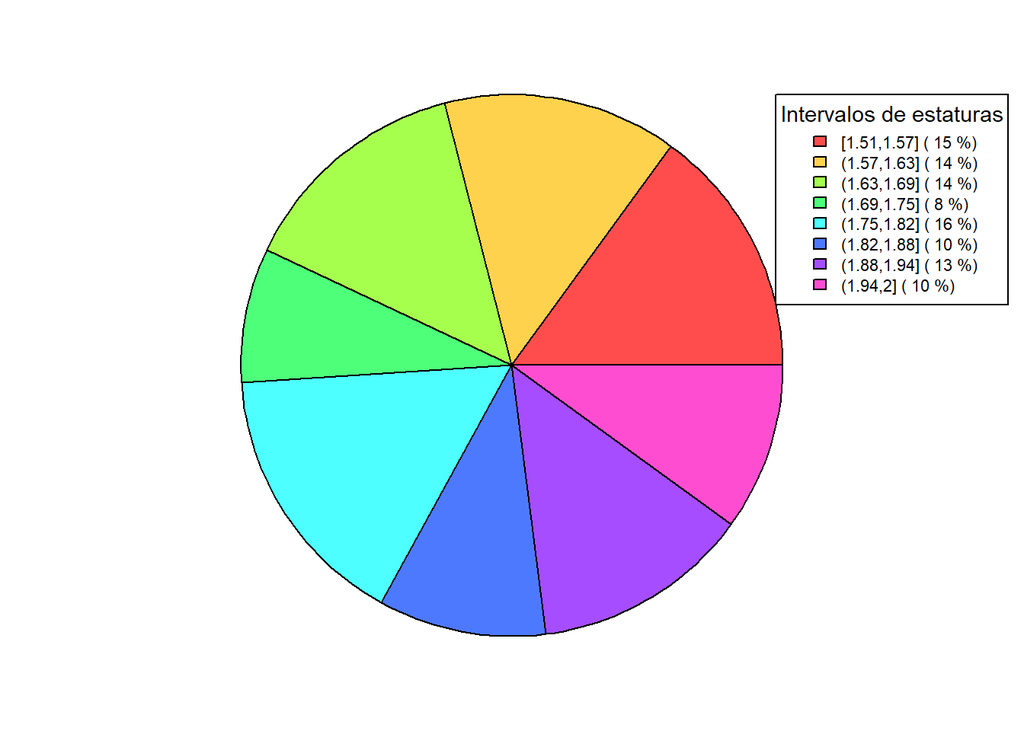

```r
par(pin = c(7, 5))
pie(tabla_intervalos,
    main = "Distribución de estatura en metros",
    col = rainbow(length(tabla_intervalos), 0.7),
    labels = NA,
    cex.main = 1.5)

legend(x =0.78, y = 0.8,
       legend = paste(names(tabla_intervalos), "(", porcentajes_intervalos, "%)"),
       fill = rainbow(length(tabla_intervalos), 0.7),
       cex = 0.7,
       title = "Intervalos de estaturas",
       title.cex = 0.9)
```

#### Gráfica de ojiva

Generamos la gráfica de ojiva

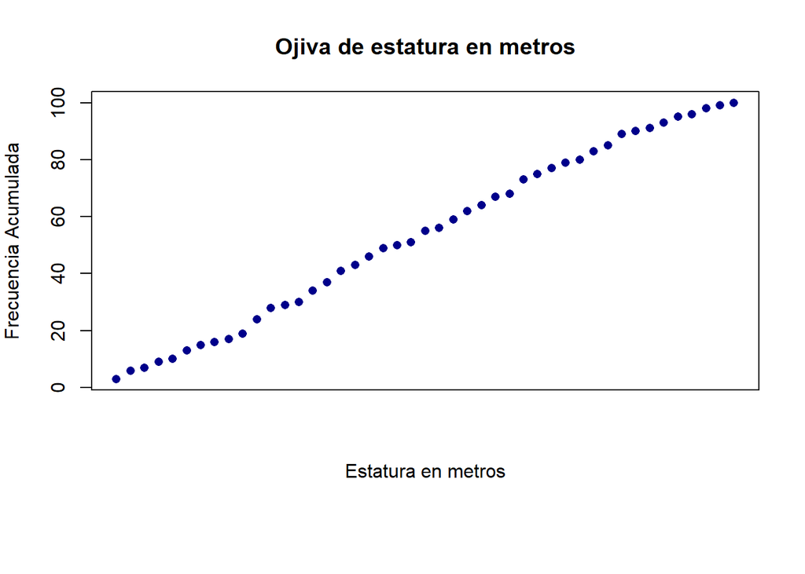

```r
par(mar=c(8,4,4,2))
frec_acum <- cumsum(table(factor(estatura)))
plot(frec_acum, type = "b", pch = 16, col = "darkblue",
     main = "Ojiva de estatura en metros",
     xlab = "Estatura en metros",
     ylab = "Frecuencia Acumulada",
     xaxt = "n")
```

#### Gráfica de dispersión

```r
indices <- 1:10; (indices)
```

```
##  [1]  1  2  3  4  5  6  7  8  9 10
```

```r
t <- cte*indices; (t)
```

```
##  [1]  9 18 27 36 45 54 63 72 81 90
```

```r
mis_deciles <- tabla_intervalos[t]; (mis_deciles)
```

```
## intervalos
## <NA> <NA> <NA> <NA> <NA> <NA> <NA> <NA> <NA> <NA>
##
```

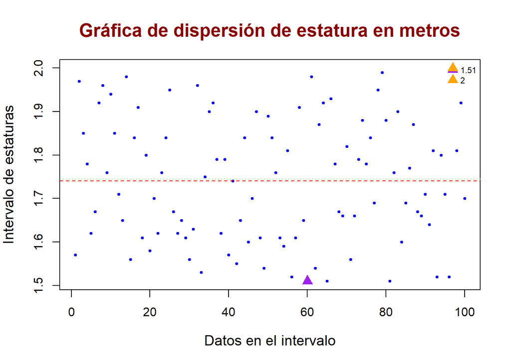

```r
plot(
  estatura,
  main = "Gráfica de dispersión de estatura en metros",
  xlab = "Datos en el intervalo",
  ylab = "Intervalo de estaturas",
  col = "blue",
  pch = 19,
  cex = 0.5,
  cex.main = 1.5,
  cex.lab = 1.2,
  col.main = "darkred")
legend(
  "topright",                  # ubicación
  legend = c(mi_min,mi_max),    # etiquetas
  pch = 17,
  col=c("purple","orange"),
  pt.cex = 1.5,                # tamaño de los símbolos
  cex = 0.7,
  bty = "n"                    # sin borde en la caja
)
abline(h = media, col = "red", lwd = 1, lty = 2)
abline(h = Q2, col = "lightgreen", lwd = 1, lty = 3)
abline(h = mis_deciles, col = "lightgray", lty = 1.5)
points(which.min(estatura), min(estatura), col = "purple", pch = 17, cex = 1.5)
points(which.max(estatura), max(estatura), col = "orange", pch = 17, cex = 1.5)
```

#### Gráfica combinada

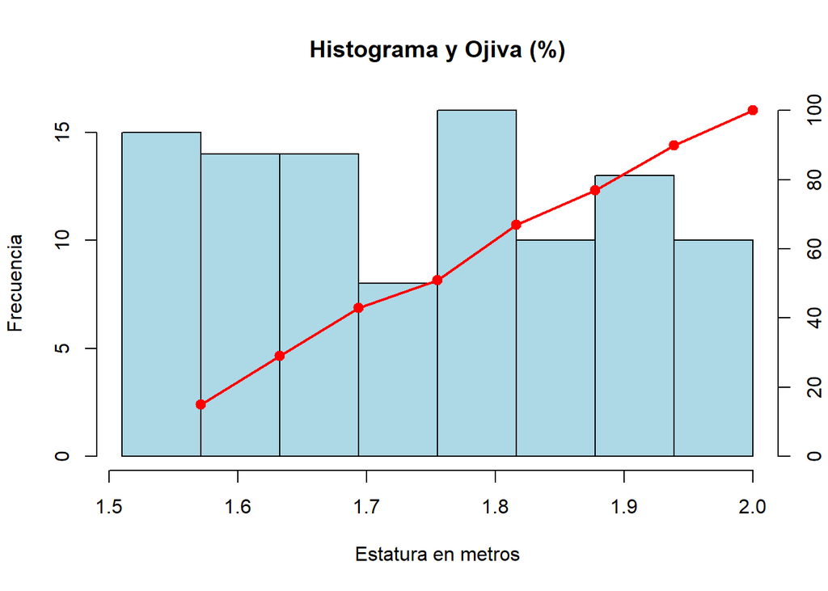

```r
nbreaks <- 10
h <- hist(estatura, breaks = breaks_exactos, plot = FALSE)
hist(estatura,
     breaks = breaks_exactos,
     col = "lightblue",
     main = "Histograma y Ojiva (%)",
     xlab = "Estatura en metros",
     ylab = "Frecuencia")
freq_acum_pct <- cumsum(h$counts) / sum(h$counts) * 100
x_vals <- h$breaks[-1]
par(new = TRUE)
plot(x_vals, freq_acum_pct,
     type = "o", pch = 19, lwd = 2, col = "red",
     axes = FALSE, xlab = "", ylab = "",
     xlim = range(h$breaks), ylim = c(0, 100))
axis(4)                           # eje derecho
```

```r
#---- Fin ----
```

## Ejercicio 9.2 Peso corporal en kilogramos:

### Datos

```r
peso<- c(100.5, 91.3, 60.4, 83.2, 49.6, 103.1, 60.3, 109.3, 83.5, 63.9, 106, 50, 47, 89.7, 108.5, 78.9, 82.7, 60.7, 98.7, 85.2, 48.7, 106.7, 63.9, 84.1, 69.5, 53.3, 108.9, 91.8, 108.6, 54.5, 95.1, 90.6, 115.9, 88.5, 67.7, 115.1, 108.3, 76.8, 81.4, 102.6, 63.9, 105.9, 106.7, 76.3, 113.7, 50.3, 105.8, 81.4, 67.9, 91.3, 68.9, 93.9, 113.7, 87.7, 92.8, 76.2, 104.7, 109.7, 72.6, 81.6, 112.2, 79.8, 60.7, 95.7, 100.1, 94, 60.5, 117.1, 45.5, 112.7, 51.7, 107.8, 86.6, 90.3, 105.9, 64.7, 48, 55.4, 52.9, 58.2, 117.1, 59.6, 69.9, 96.9, 97, 66.5, 67.4, 77.2, 73.7, 113)
```

### Procesamiento de datos (Ordenar)

Primero obtenemos un resumen de los datos generados

```r
summary(peso)
```

```
##    Min. 1st Qu.  Median    Mean 3rd Qu.    Max.
##   45.50   65.15   84.65   83.86  104.30  117.10
```

### Frecuencias (Clasificar)

Obtenemos las frecuencias de los datos.

```r
(peso) #Datos
```

```
##  [1] 100.5  91.3  60.4  83.2  49.6 103.1  60.3 109.3  83.5  63.9 106.0  50.0
## [13]  47.0  89.7 108.5  78.9  82.7  60.7  98.7  85.2  48.7 106.7  63.9  84.1
## [25]  69.5  53.3 108.9  91.8 108.6  54.5  95.1  90.6 115.9  88.5  67.7 115.1
## [37] 108.3  76.8  81.4 102.6  63.9 105.9 106.7  76.3 113.7  50.3 105.8  81.4
## [49]  67.9  91.3  68.9  93.9 113.7  87.7  92.8  76.2 104.7 109.7  72.6  81.6
## [61] 112.2  79.8  60.7  95.7 100.1  94.0  60.5 117.1  45.5 112.7  51.7 107.8
## [73]  86.6  90.3 105.9  64.7  48.0  55.4  52.9  58.2 117.1  59.6  69.9  96.9
## [85]  97.0  66.5  67.4  77.2  73.7 113.0
```

```r
peso_ord<- sort(peso) #Datos ordenados por clase
(peso_ord)
```

```
##  [1]  45.5  47.0  48.0  48.7  49.6  50.0  50.3  51.7  52.9  53.3  54.5  55.4
## [13]  58.2  59.6  60.3  60.4  60.5  60.7  60.7  63.9  63.9  63.9  64.7  66.5
## [25]  67.4  67.7  67.9  68.9  69.5  69.9  72.6  73.7  76.2  76.3  76.8  77.2
## [37]  78.9  79.8  81.4  81.4  81.6  82.7  83.2  83.5  84.1  85.2  86.6  87.7
## [49]  88.5  89.7  90.3  90.6  91.3  91.3  91.8  92.8  93.9  94.0  95.1  95.7
## [61]  96.9  97.0  98.7 100.1 100.5 102.6 103.1 104.7 105.8 105.9 105.9 106.0
## [73] 106.7 106.7 107.8 108.3 108.5 108.6 108.9 109.3 109.7 112.2 112.7 113.0
## [85] 113.7 113.7 115.1 115.9 117.1 117.1
```

```r
contador <- table(peso) #Frecuencia de los datos
(contador)
```

```
## peso
##  45.5    47    48  48.7  49.6    50  50.3  51.7  52.9  53.3  54.5  55.4  58.2
##     1     1     1     1     1     1     1     1     1     1     1     1     1
##  59.6  60.3  60.4  60.5  60.7  63.9  64.7  66.5  67.4  67.7  67.9  68.9  69.5
##     1     1     1     1     2     3     1     1     1     1     1     1     1
##  69.9  72.6  73.7  76.2  76.3  76.8  77.2  78.9  79.8  81.4  81.6  82.7  83.2
##     1     1     1     1     1     1     1     1     1     2     1     1     1
##  83.5  84.1  85.2  86.6  87.7  88.5  89.7  90.3  90.6  91.3  91.8  92.8  93.9
##     1     1     1     1     1     1     1     1     1     2     1     1     1
##    94  95.1  95.7  96.9    97  98.7 100.1 100.5 102.6 103.1 104.7 105.8 105.9
##     1     1     1     1     1     1     1     1     1     1     1     1     2
##   106 106.7 107.8 108.3 108.5 108.6 108.9 109.3 109.7 112.2 112.7   113 113.7
##     1     2     1     1     1     1     1     1     1     1     1     1     2
## 115.1 115.9 117.1
##     1     1     2
```

```r
cte<- 9
```

### Proporciones

Obtenemos las proporciones.

```r
prop.table(table(peso)) #Proporciones
```

```
## peso
##       45.5         47         48       48.7       49.6         50       50.3
## 0.01111111 0.01111111 0.01111111 0.01111111 0.01111111 0.01111111 0.01111111
##       51.7       52.9       53.3       54.5       55.4       58.2       59.6
## 0.01111111 0.01111111 0.01111111 0.01111111 0.01111111 0.01111111 0.01111111
##       60.3       60.4       60.5       60.7       63.9       64.7       66.5
## 0.01111111 0.01111111 0.01111111 0.02222222 0.03333333 0.01111111 0.01111111
##       67.4       67.7       67.9       68.9       69.5       69.9       72.6
## 0.01111111 0.01111111 0.01111111 0.01111111 0.01111111 0.01111111 0.01111111
##       73.7       76.2       76.3       76.8       77.2       78.9       79.8
## 0.01111111 0.01111111 0.01111111 0.01111111 0.01111111 0.01111111 0.01111111
##       81.4       81.6       82.7       83.2       83.5       84.1       85.2
## 0.02222222 0.01111111 0.01111111 0.01111111 0.01111111 0.01111111 0.01111111
##       86.6       87.7       88.5       89.7       90.3       90.6       91.3
## 0.01111111 0.01111111 0.01111111 0.01111111 0.01111111 0.01111111 0.02222222
##       91.8       92.8       93.9         94       95.1       95.7       96.9
## 0.01111111 0.01111111 0.01111111 0.01111111 0.01111111 0.01111111 0.01111111
##         97       98.7      100.1      100.5      102.6      103.1      104.7
## 0.01111111 0.01111111 0.01111111 0.01111111 0.01111111 0.01111111 0.01111111
##      105.8      105.9        106      106.7      107.8      108.3      108.5
## 0.01111111 0.02222222 0.01111111 0.02222222 0.01111111 0.01111111 0.01111111
##      108.6      108.9      109.3      109.7      112.2      112.7        113
## 0.01111111 0.01111111 0.01111111 0.01111111 0.01111111 0.01111111 0.01111111
##      113.7      115.1      115.9      117.1
## 0.02222222 0.01111111 0.01111111 0.02222222
```

### Medidas de tendencia central

#### Moda

Obtenemos la moda

```r
# Función para detectar modalidad
max_frecuencia <- max(contador)
modas <- names(contador)[contador == max_frecuencia]

# Identificar e imprimir resultado
if(length(modas) == 1) {
  cat("UNIMODAL - Moda:", modas)
} else if(length(modas) == 2) {
  cat("BIMODAL - Modas:", paste(modas, collapse = " y "))
} else {
  cat("Hay más de dos clases con mayor frecuencia por lo tanto no hay moda")
}
```

```
## UNIMODAL - Moda: 63.9
```

#### Mediana

Obtenemos la mediana

```r
  # Calcular mediana
  mediana<- median(peso)
  cat("La mediana es:", mediana, "\n")
```

```
## La mediana es: 84.65
```

#### Media

Obtenemos la media

```r
media<-mean(peso)
cat("La media es:", media, "\n")
```

```
## La media es: 83.86222
```

### Medidas de localización

#### Cuartiles

```r
cuantiles <- quantile(peso_ord); (cuantiles)
```

```
##     0%    25%    50%    75%   100%
##  45.50  65.15  84.65 104.30 117.10
```

```r
Q1 <- cuantiles[2]; (Q1)
```

```
##   25%
## 65.15
```

```r
Q2 <- cuantiles[3]; (Q2)
```

```
##   50%
## 84.65
```

```r
Q3 <- cuantiles[4]; (Q3)
```

```
##   75%
## 104.3
```

Calculemos el valor máximo y el valor mínimo para los datos

```r
mi_min <- min(peso);
(mi_min)
```

```
## [1] 45.5
```

```r
mi_max <- max(peso);
(mi_max)
```

```
## [1] 117.1
```

### Diagrama de caja y brazos

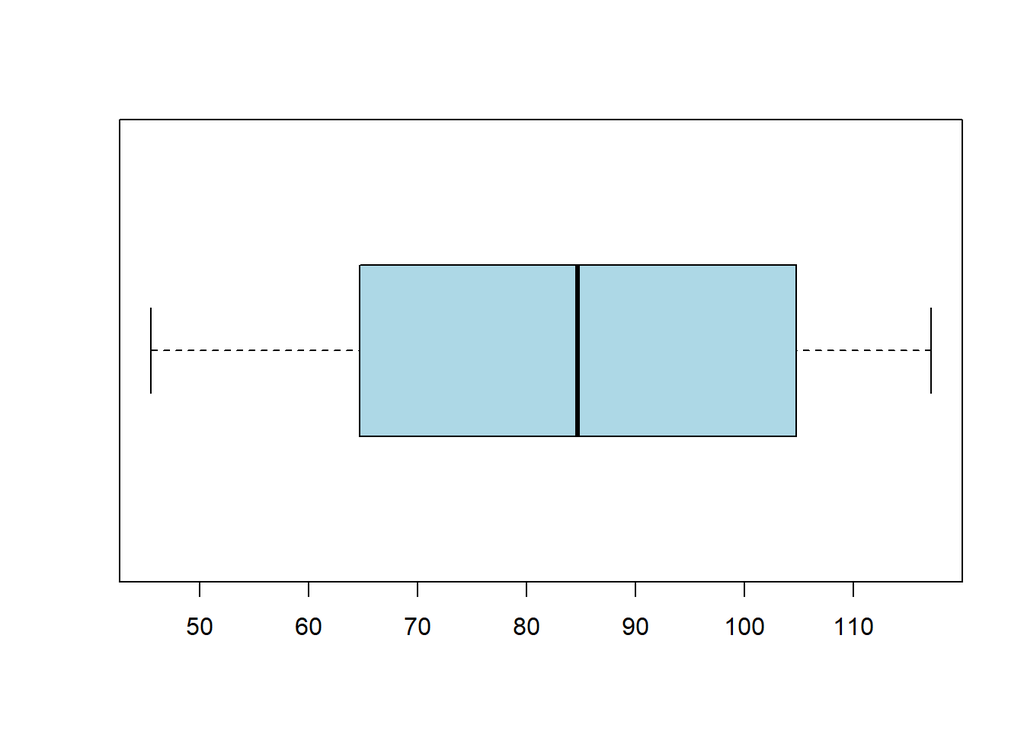

```r
boxplot(peso_ord, horizontal = TRUE, col = "lightblue")
```

### Medidas de dispersión

#### Varianza

```r
varianza <- var(peso); (varianza)
```

```
## [1] 450.4363
```

#### Desviación estándar

```r
DesvEst <- sd(peso); (DesvEst)
```

```
## [1] 21.22348
```

### Gráficos

Comenzamos a graficar.

#### Generemos la gráfica de barras.

```r
# Regla de Sturges lo que nos da el número de intervalos
n <- length(peso)
nbreaks <- round(1 + 3.322 * log10(n))
(nbreaks)
```

```
## [1] 7
```

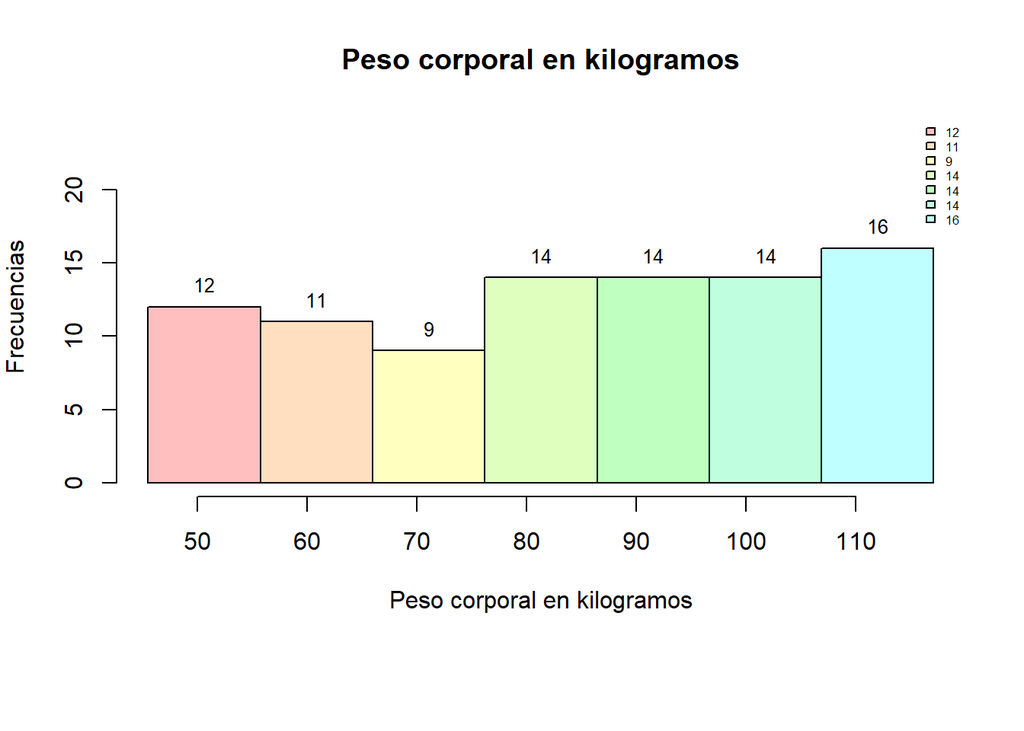

```r
rango <- range(peso)
breaks_exactos <- seq(from = rango[1], to = rango[2], length.out = nbreaks + 1)

par(mar=c(8,4,4,2))
miscolores <- rainbow(12,0.25)
gb <- hist(peso, breaks = breaks_exactos, plot = FALSE) #histograma simple de los datos
gb2 <- hist(peso, breaks = breaks_exactos, col = miscolores,
          main = "Peso corporal en kilogramos",
          xlab = "Peso corporal en kilogramos",
          ylab = "Frecuencias",
          ylim = c(0, max(gb$counts)*1.5))

text(gb2$mids, gb2$counts, labels = gb2$counts, pos = 3, cex = 0.8,
     col = "black")

nl <- length(gb2$counts)
legend(
  "topright",
  legend = gb2$counts,
  fill = miscolores[1:nl],  # Solo los colores necesarios
  pt.cex = 1.5,
  cex = 0.5,
  bty = "n"
)
```

#### Gráfica de porcentajes

Generamos la gráfica de porcentajes.

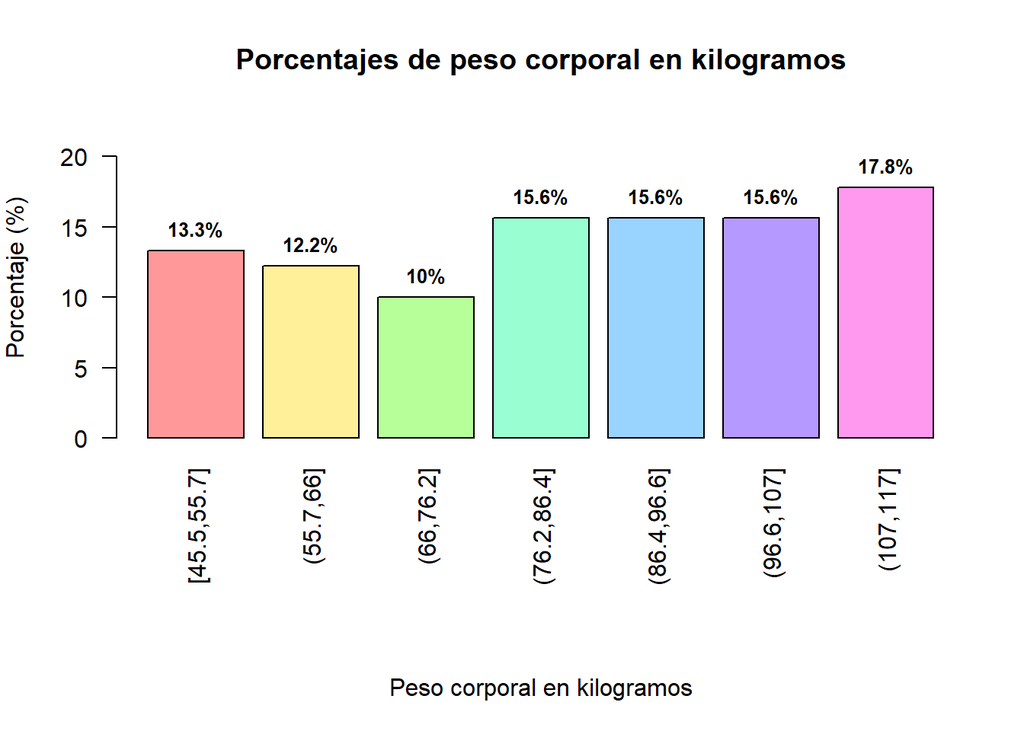

```r
par(mar=c(10,4,4,2))

intervalos <- cut(peso, breaks = breaks_exactos, include.lowest = TRUE)
tabla_intervalos <- table(intervalos)
porcentajes_intervalos <- round(prop.table(tabla_intervalos) * 100, 1)
gp <- barplot(porcentajes_intervalos,
                 col = rainbow(length(tabla_intervalos), 0.4),
                 main = "Porcentajes de peso corporal en kilogramos",
                 xlab = "",
                 ylab = "Porcentaje (%)",
                 ylim = c(0, max(porcentajes_intervalos) + 5),
                 las = 2)  # Etiquetas verticales

title(xlab = "Peso corporal en kilogramos", line = 8)

# Agregar valores encima de barras
text(x = gp,
     y = porcentajes_intervalos,
     labels = paste0(porcentajes_intervalos, "%"),
     pos = 3,
     cex = 0.8,
     font = 2)
```

#### Gráfica de pasteles

Generamos la gráfica de pasteles.

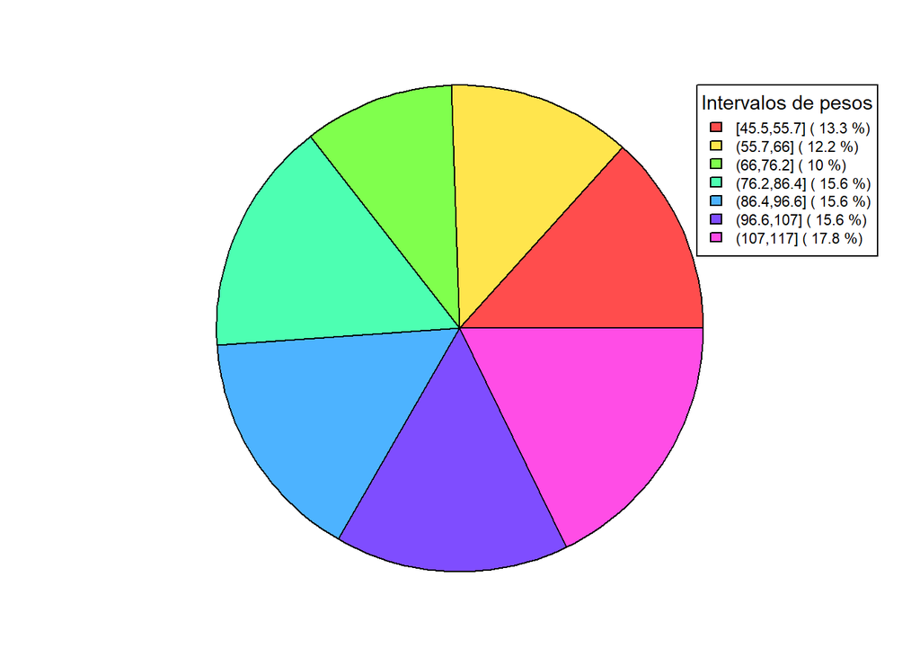

```r
par(pin = c(7, 5))
pie(tabla_intervalos,
    main = "Distribución de peso corporal en kilogramos",
    col = rainbow(length(tabla_intervalos), 0.7),
    labels = NA,
    cex.main = 1.5)

legend(x =0.78, y = 0.8,
       legend = paste(names(tabla_intervalos), "(", porcentajes_intervalos, "%)"),
       fill = rainbow(length(tabla_intervalos), 0.7),
       cex = 0.7,
       title = "Intervalos de pesos",
       title.cex = 0.9)
```

#### Gráfica de ojiva

Generamos la gráfica de ojiva

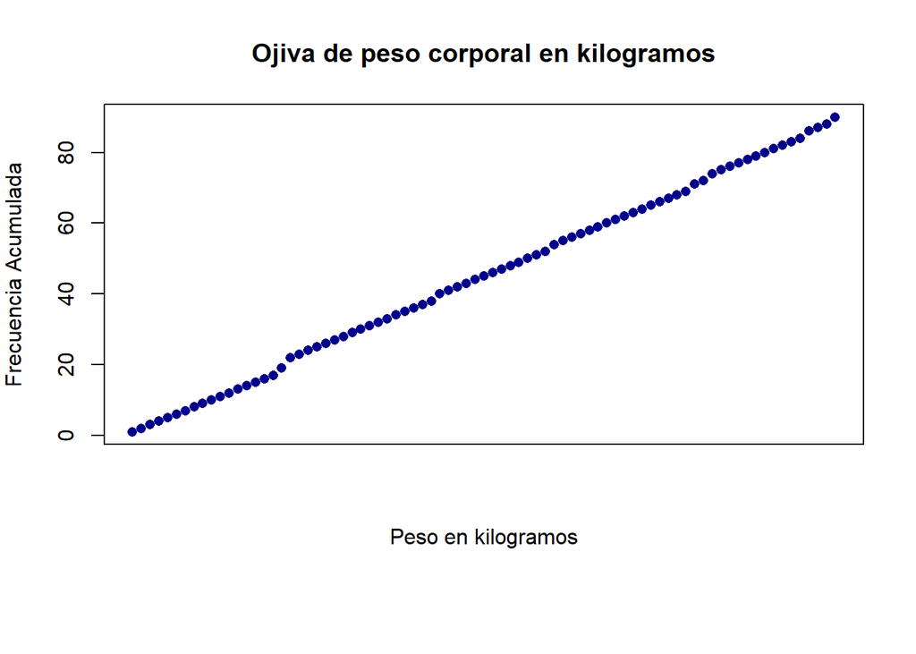

```r
par(mar=c(8,4,4,2))
frec_acum <- cumsum(table(factor(peso)))
plot(frec_acum, type = "b", pch = 16, col = "darkblue",
     main = "Ojiva de peso corporal en kilogramos",
     xlab = "Peso en kilogramos",
     ylab = "Frecuencia Acumulada",
     xaxt = "n")
```

#### Gráfica de dispersión

```r
indices <- 1:10; (indices)
```

```
##  [1]  1  2  3  4  5  6  7  8  9 10
```

```r
t <- cte*indices; (t)
```

```
##  [1]  9 18 27 36 45 54 63 72 81 90
```

```r
mis_deciles <- tabla_intervalos[t]; (mis_deciles)
```

```
## intervalos
## <NA> <NA> <NA> <NA> <NA> <NA> <NA> <NA> <NA> <NA>
##
```

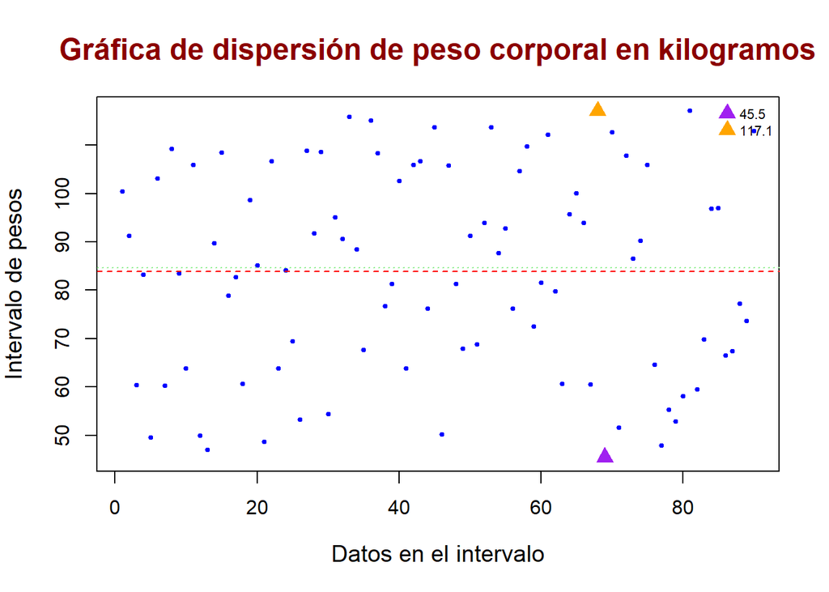

```r
plot(peso,
  main = "Gráfica de dispersión de peso corporal en kilogramos",
  xlab = "Datos en el intervalo",
  ylab = "Intervalo de pesos",
  col = "blue",
  pch = 19,
  cex = 0.5,
  cex.main = 1.5,
  cex.lab = 1.2,
  col.main = "darkred")
legend(
  "topright",                  # ubicación
  legend = c(mi_min,mi_max),    # etiquetas
  pch = 17,
  col=c("purple","orange"),
  pt.cex = 1.5,                # tamaño de los símbolos
  cex = 0.7,
  bty = "n"                    # sin borde en la caja
)
abline(h = media, col = "red", lwd = 1, lty = 2)
abline(h = Q2, col = "lightgreen", lwd = 1, lty = 3)
abline(h = mis_deciles, col = "lightgray", lty = 1.5)
points(which.min(peso), min(peso), col = "purple", pch = 17, cex = 1.5)
points(which.max(peso), max(peso), col = "orange", pch = 17, cex = 1.5)
```

#### Gráfica combinada

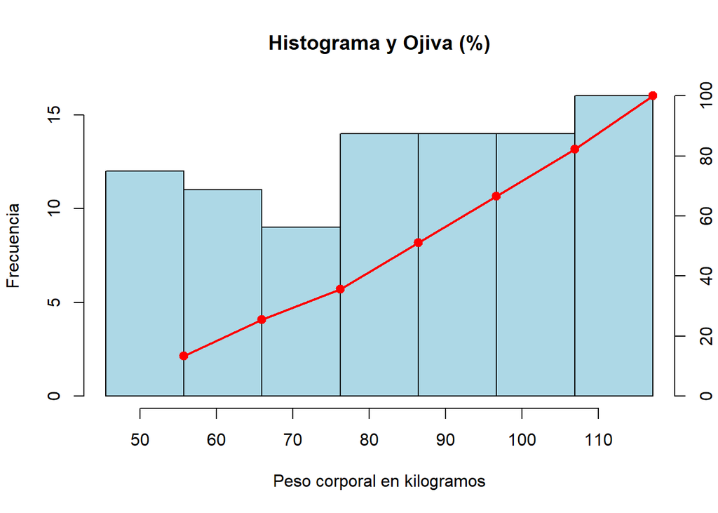

```r
nbreaks <- 10
h <- hist(peso, breaks = breaks_exactos, plot = FALSE)
hist(peso,
     breaks = breaks_exactos,
     col = "lightblue",
     main = "Histograma y Ojiva (%)",
     xlab = "Peso corporal en kilogramos",
     ylab = "Frecuencia")
freq_acum_pct <- cumsum(h$counts) / sum(h$counts) * 100
x_vals <- h$breaks[-1]
par(new = TRUE)
plot(x_vals, freq_acum_pct,
     type = "o", pch = 19, lwd = 2, col = "red",
     axes = FALSE, xlab = "", ylab = "",
     xlim = range(h$breaks), ylim = c(0, 100))
axis(4)                           # eje derecho
```

```r
#---- Fin ----
```

## Ejercicio 9.3 Nivel de contaminación en la delegación Iztapalapa en el mes de julio:

### Datos

```r
contaminacion<- c(0.7, 0.4, 0.4, 0.5, 0.3, 0.3, 0.7, 0.5, 0.2, 0.2, 0.5, 0.8, 0.3, 0.9, 0.5, 0.2, 0.4, 0.4, 0.7, 0.6, 0.8, 0.3, 1, 0.7, 1.5, 0.1, 0.1, 0.9, 0.1, 0.3, 0.9, 0.3, 1.2, 1.2, 1.2, 0.6, 0.7, 0.4, 1.8, 0.2, 0.6, 0.7, 1.7, 0.4, 0.9, 0.2, 0.8, 1, 0.7, 0.6, 0.7, 0.3, 0.5, 0.2, 1.2, 0.5, 0.8, 0.2, 0.4, 0.3, 0.4, 0.5, 0.5, 1.4, 0.4)
```

### Procesamiento de datos (Ordenar)

Primero obtenemos un resumen de los datos generados

```r
summary(contaminacion)
```

```
##    Min. 1st Qu.  Median    Mean 3rd Qu.    Max.
##  0.1000  0.3000  0.5000  0.6108  0.8000  1.8000
```

### Frecuencias (Clasificar)

Obtenemos las frecuencias de los datos.

```r
(contaminacion) #Datos
```

```
##  [1] 0.7 0.4 0.4 0.5 0.3 0.3 0.7 0.5 0.2 0.2 0.5 0.8 0.3 0.9 0.5 0.2 0.4 0.4 0.7
## [20] 0.6 0.8 0.3 1.0 0.7 1.5 0.1 0.1 0.9 0.1 0.3 0.9 0.3 1.2 1.2 1.2 0.6 0.7 0.4
## [39] 1.8 0.2 0.6 0.7 1.7 0.4 0.9 0.2 0.8 1.0 0.7 0.6 0.7 0.3 0.5 0.2 1.2 0.5 0.8
## [58] 0.2 0.4 0.3 0.4 0.5 0.5 1.4 0.4
```

```r
contaminacion_ord<- sort(contaminacion) #Datos ordenados por clase
(contaminacion_ord)
```

```
##  [1] 0.1 0.1 0.1 0.2 0.2 0.2 0.2 0.2 0.2 0.2 0.3 0.3 0.3 0.3 0.3 0.3 0.3 0.3 0.4
## [20] 0.4 0.4 0.4 0.4 0.4 0.4 0.4 0.4 0.5 0.5 0.5 0.5 0.5 0.5 0.5 0.5 0.6 0.6 0.6
## [39] 0.6 0.7 0.7 0.7 0.7 0.7 0.7 0.7 0.7 0.8 0.8 0.8 0.8 0.9 0.9 0.9 0.9 1.0 1.0
## [58] 1.2 1.2 1.2 1.2 1.4 1.5 1.7 1.8
```

```r
contador <- table(contaminacion) #Frecuencia de los datos
(contador)
```

```
## contaminacion
## 0.1 0.2 0.3 0.4 0.5 0.6 0.7 0.8 0.9   1 1.2 1.4 1.5 1.7 1.8
##   3   7   8   9   8   4   8   4   4   2   4   1   1   1   1
```

```r
cte<- 9
```

### Proporciones

Obtenemos las proporciones.

```r
prop.table(table(contaminacion)) #Proporciones
```

```
## contaminacion
##        0.1        0.2        0.3        0.4        0.5        0.6        0.7
## 0.04615385 0.10769231 0.12307692 0.13846154 0.12307692 0.06153846 0.12307692
##        0.8        0.9          1        1.2        1.4        1.5        1.7
## 0.06153846 0.06153846 0.03076923 0.06153846 0.01538462 0.01538462 0.01538462
##        1.8
## 0.01538462
```

### Medidas de tendencia central

#### Moda

Obtenemos la moda

```r
# Función para detectar modalidad
max_frecuencia <- max(contador)
modas <- names(contador)[contador == max_frecuencia]

# Identificar e imprimir resultado
if(length(modas) == 1) {
  cat("UNIMODAL - Moda:", modas)
} else if(length(modas) == 2) {
  cat("BIMODAL - Modas:", paste(modas, collapse = " y "))
} else {
  cat("Hay más de dos clases con mayor frecuencia por lo tanto no hay moda")
}
```

```
## UNIMODAL - Moda: 0.4
```

#### Mediana

Obtenemos la mediana

```r
  # Calcular mediana
  mediana<- median(contaminacion)
  cat("La mediana es:", mediana, "\n")
```

```
## La mediana es: 0.5
```

#### Media

Obtenemos la media

```r
media<-mean(contaminacion)
cat("La media es:", media, "\n")
```

```
## La media es: 0.6107692
```

### Medidas de localización

#### Cuartiles

```r
cuantiles <- quantile(contaminacion_ord); (cuantiles)
```

```
##   0%  25%  50%  75% 100%
##  0.1  0.3  0.5  0.8  1.8
```

```r
Q1 <- cuantiles[2]; (Q1)
```

```
## 25%
## 0.3
```

```r
Q2 <- cuantiles[3]; (Q2)
```

```
## 50%
## 0.5
```

```r
Q3 <- cuantiles[4]; (Q3)
```

```
## 75%
## 0.8
```

Calculemos el valor máximo y el valor mínimo para los datos

```r
mi_min <- min(contaminacion);
(mi_min)
```

```
## [1] 0.1
```

```r
mi_max <- max(contaminacion);
(mi_max)
```

```
## [1] 1.8
```

### Diagrama de caja y brazos

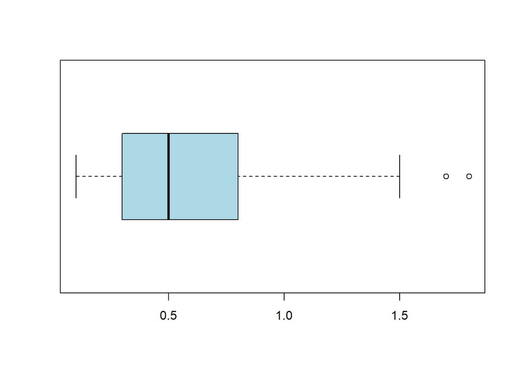

```r
boxplot(contaminacion_ord, horizontal = TRUE, col = "lightblue")
```

### Medidas de dispersión

#### Varianza

```r
varianza <- var(contaminacion); (varianza)
```

```
## [1] 0.1481635
```

#### Desviación estándar

```r
DesvEst <- sd(contaminacion); (DesvEst)
```

```
## [1] 0.3849201
```

### Gráficos

Comenzamos a graficar.

#### Generemos la gráfica de barras.

```r
# Regla de Sturges lo que nos da el número de intervalos
n <- length(contaminacion)
nbreaks <- round(1 + 3.322 * log10(n))
(nbreaks)
```

```
## [1] 7
```

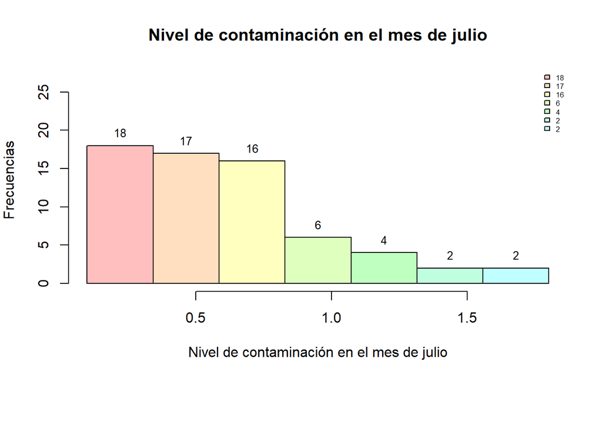

```r
rango <- range(contaminacion)
breaks_exactos <- seq(from = rango[1], to = rango[2], length.out = nbreaks + 1)

par(mar=c(8,4,4,2))
miscolores <- rainbow(12,0.25)
gb <- hist(contaminacion, breaks = breaks_exactos, plot = FALSE) #histograma simple de los datos
gb2 <- hist(contaminacion, breaks = breaks_exactos, col = miscolores,
          main = "Nivel de contaminación en el mes de julio",
          xlab = "Nivel de contaminación en el mes de julio",
          ylab = "Frecuencias",
          ylim = c(0, max(gb$counts)*1.5))

text(gb2$mids, gb2$counts, labels = gb2$counts, pos = 3, cex = 0.8,
     col = "black")

nl <- length(gb2$counts)
legend(
  "topright",
  legend = gb2$counts,
  fill = miscolores[1:nl],  # Solo los colores necesarios
  pt.cex = 1.5,
  cex = 0.5,
  bty = "n"
)
```

#### Gráfica de porcentajes

Generamos la gráfica de porcentajes.

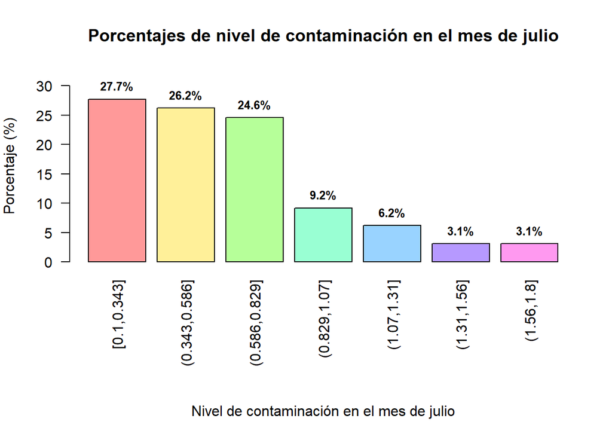

```r
par(mar=c(10,4,4,2))

intervalos <- cut(contaminacion, breaks = breaks_exactos, include.lowest = TRUE)
tabla_intervalos <- table(intervalos)
porcentajes_intervalos <- round(prop.table(tabla_intervalos) * 100, 1)
gp <- barplot(porcentajes_intervalos,
                 col = rainbow(length(tabla_intervalos), 0.4),
                 main = "Porcentajes de nivel de contaminación en el mes de julio",
                 xlab = "",
                 ylab = "Porcentaje (%)",
                 ylim = c(0, max(porcentajes_intervalos) + 5),
                 las = 2)  # Etiquetas verticales

title(xlab = "Nivel de contaminación en el mes de julio", line = 8)

# Agregar valores encima de barras
text(x = gp,
     y = porcentajes_intervalos,
     labels = paste0(porcentajes_intervalos, "%"),
     pos = 3,
     cex = 0.8,
     font = 2)
```

#### Gráfica de pasteles

Generamos la gráfica de pasteles.

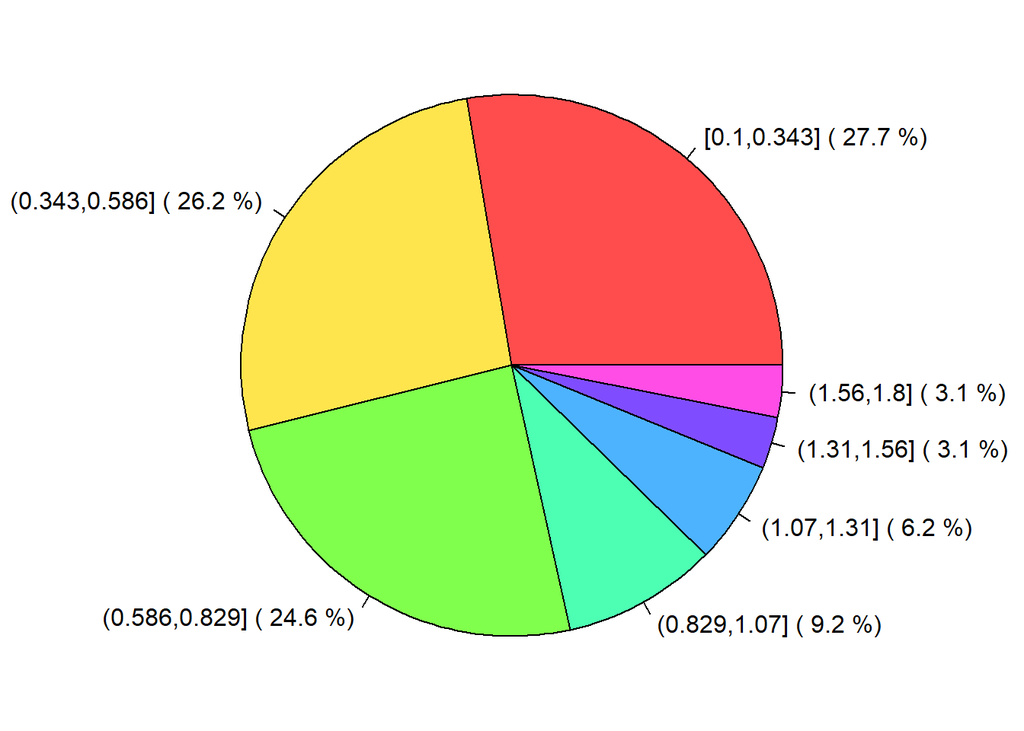

```r
par(pin = c(7, 5))
pie(tabla_intervalos,
    main = "Distribución de nivel de contaminación en el mes de julio",
    col = rainbow(length(tabla_intervalos), 0.7),
    labels = paste(names(tabla_intervalos), "(", porcentajes_intervalos, "%)"),,
    cex.main = 1.5)
```

#### Gráfica de ojiva

Generamos la gráfica de ojiva

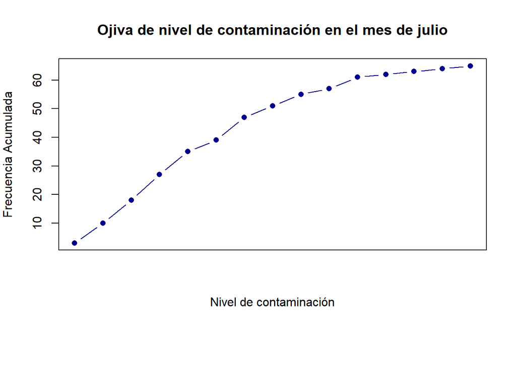

```r
par(mar=c(8,4,4,2))
frec_acum <- cumsum(table(factor(contaminacion)))
plot(frec_acum, type = "b", pch = 16, col = "darkblue",
     main = "Ojiva de nivel de contaminación en el mes de julio",
     xlab = "Nivel de contaminación",
     ylab = "Frecuencia Acumulada",
     xaxt = "n")
```

#### Gráfica de dispersión

```r
indices <- 1:10; (indices)
```

```
##  [1]  1  2  3  4  5  6  7  8  9 10
```

```r
t <- cte*indices; (t)
```

```
##  [1]  9 18 27 36 45 54 63 72 81 90
```

```r
mis_deciles <- tabla_intervalos[t]; (mis_deciles)
```

```
## intervalos
## <NA> <NA> <NA> <NA> <NA> <NA> <NA> <NA> <NA> <NA>
##
```

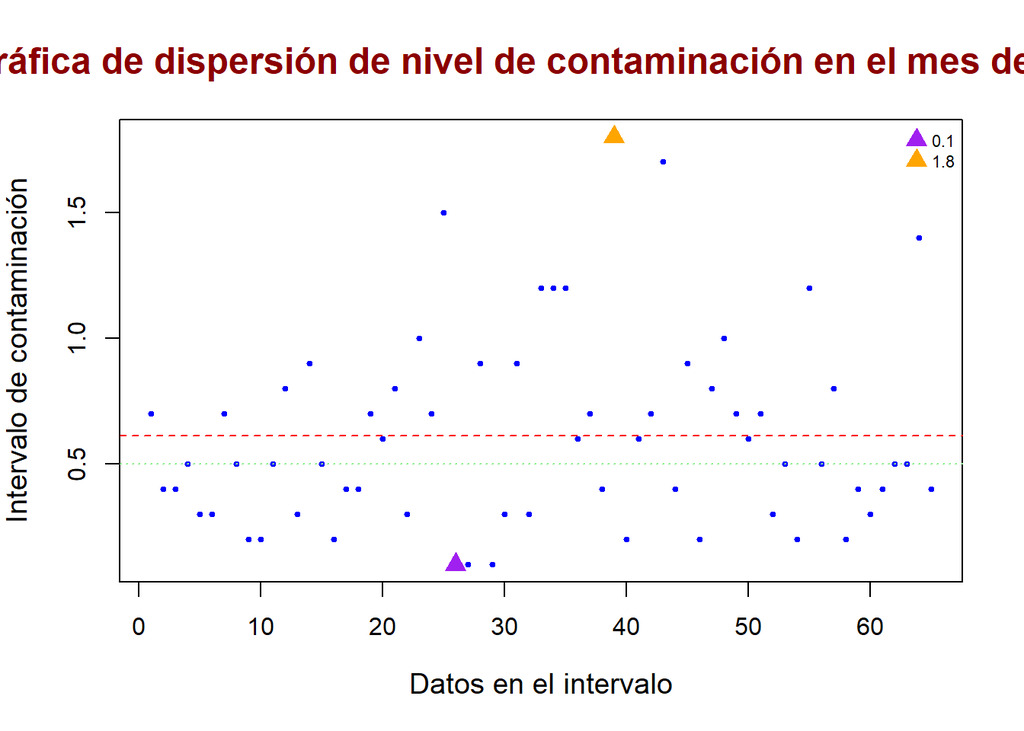

```r
plot(contaminacion,
  main = "Gráfica de dispersión de nivel de contaminación en el mes de julio",
  xlab = "Datos en el intervalo",
  ylab = "Intervalo de contaminación",
  col = "blue",
  pch = 19,
  cex = 0.5,
  cex.main = 1.5,
  cex.lab = 1.2,
  col.main = "darkred")
legend(
  "topright",                  # ubicación
  legend = c(mi_min,mi_max),    # etiquetas
  pch = 17,
  col=c("purple","orange"),
  pt.cex = 1.5,                # tamaño de los símbolos
  cex = 0.7,
  bty = "n"                    # sin borde en la caja
)
abline(h = media, col = "red", lwd = 1, lty = 2)
abline(h = Q2, col = "lightgreen", lwd = 1, lty = 3)
abline(h = mis_deciles, col = "lightgray", lty = 1.5)
points(which.min(contaminacion), min(contaminacion), col = "purple", pch = 17, cex = 1.5)
points(which.max(contaminacion), max(contaminacion), col = "orange", pch = 17, cex = 1.5)
```

#### Gráfica combinada

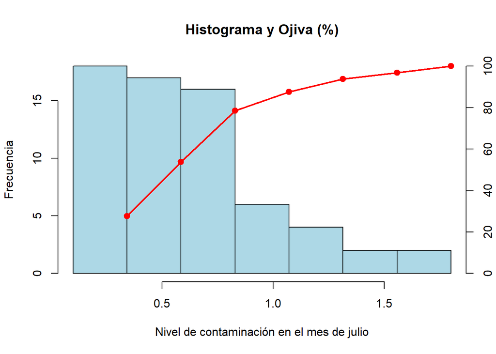

```r
nbreaks <- 10
h <- hist(contaminacion, breaks = breaks_exactos, plot = FALSE)
hist(contaminacion,
     breaks = breaks_exactos,
     col = "lightblue",
     main = "Histograma y Ojiva (%)",
     xlab = "Nivel de contaminación en el mes de julio",
     ylab = "Frecuencia")
freq_acum_pct <- cumsum(h$counts) / sum(h$counts) * 100
x_vals <- h$breaks[-1]
par(new = TRUE)
plot(x_vals, freq_acum_pct,
     type = "o", pch = 19, lwd = 2, col = "red",
     axes = FALSE, xlab = "", ylab = "",
     xlim = range(h$breaks), ylim = c(0, 100))
axis(4)                           # eje derecho
```

```r
#---- Fin ----
```